# R3_External_Lab_Logistic_and_Naive_bayes_questions

## Question 3

## Drop missing values

*Set the index name of the dataframe to **"number"**. Check sample of data to drop if any missing values are there.*

#### Answer:

```python
data1.index.rename("number",inplace =True)    # Renaming the index column with name "number"
data1
```

| number | school | sex | age | address | famsize | Pstatus | Medu | Fedu | Mjob | Fjob | ... | famrel | freetime | goout | Dalc | Walc | health | absences | G1 | G2 | G3 |
| --- | --- | --- | --- | --- | --- | --- | --- | --- | --- | --- | --- | --- | --- | --- | --- | --- | --- | --- | --- | --- | --- |
| 0 | GP | F | 18 | U | GT3 | A | 4 | 4 | at_home | teacher | ... | 4 | 3 | 4 | 1 | 1 | 3 | 6 | 5 | 6 | 6 |
| 1 | GP | F | 17 | U | GT3 | T | 1 | 1 | at_home | other | ... | 5 | 3 | 3 | 1 | 1 | 3 | 4 | 5 | 5 | 6 |
| 2 | GP | F | 15 | U | LE3 | T | 1 | 1 | at_home | other | ... | 4 | 3 | 2 | 2 | 3 | 3 | 10 | 7 | 8 | 10 |
| 3 | GP | F | 15 | U | GT3 | T | 4 | 2 | health | services | ... | 3 | 2 | 2 | 1 | 1 | 5 | 2 | 15 | 14 | 15 |
| 4 | GP | F | 16 | U | GT3 | T | 3 | 3 | other | other | ... | 4 | 3 | 2 | 1 | 2 | 5 | 4 | 6 | 10 | 10 |
| 5 | GP | M | 16 | U | LE3 | T | 4 | 3 | services | other | ... | 5 | 4 | 2 | 1 | 2 | 5 | 10 | 15 | 15 | 15 |
| 6 | GP | M | 16 | U | LE3 | T | 2 | 2 | other | other | ... | 4 | 4 | 4 | 1 | 1 | 3 | 0 | 12 | 12 | 11 |
| 7 | GP | F | 17 | U | GT3 | A | 4 | 4 | other | teacher | ... | 4 | 1 | 4 | 1 | 1 | 1 | 6 | 6 | 5 | 6 |
| 8 | GP | M | 15 | U | LE3 | A | 3 | 2 | services | other | ... | 4 | 2 | 2 | 1 | 1 | 1 | 0 | 16 | 18 | 19 |
| 9 | GP | M | 15 | U | GT3 | T | 3 | 4 | other | other | ... | 5 | 5 | 1 | 1 | 1 | 5 | 0 | 14 | 15 | 15 |
| 10 | GP | F | 15 | U | GT3 | T | 4 | 4 | teacher | health | ... | 3 | 3 | 3 | 1 | 2 | 2 | 0 | 10 | 8 | 9 |
| 11 | GP | F | 15 | U | GT3 | T | 2 | 1 | services | other | ... | 5 | 2 | 2 | 1 | 1 | 4 | 4 | 10 | 12 | 12 |
| 12 | GP | M | 15 | U | LE3 | T | 4 | 4 | health | services | ... | 4 | 3 | 3 | 1 | 3 | 5 | 2 | 14 | 14 | 14 |
| 13 | GP | M | 15 | U | GT3 | T | 4 | 3 | teacher | other | ... | 5 | 4 | 3 | 1 | 2 | 3 | 2 | 10 | 10 | 11 |
| 14 | GP | M | 15 | U | GT3 | A | 2 | 2 | other | other | ... | 4 | 5 | 2 | 1 | 1 | 3 | 0 | 14 | 16 | 16 |
| 15 | GP | F | 16 | U | GT3 | T | 4 | 4 | health | other | ... | 4 | 4 | 4 | 1 | 2 | 2 | 4 | 14 | 14 | 14 |
| 16 | GP | F | 16 | U | GT3 | T | 4 | 4 | services | services | ... | 3 | 2 | 3 | 1 | 2 | 2 | 6 | 13 | 14 | 14 |
| 17 | GP | F | 16 | U | GT3 | T | 3 | 3 | other | other | ... | 5 | 3 | 2 | 1 | 1 | 4 | 4 | 8 | 10 | 10 |
| 18 | GP | M | 17 | U | GT3 | T | 3 | 2 | services | services | ... | 5 | 5 | 5 | 2 | 4 | 5 | 16 | 6 | 5 | 5 |
| 19 | GP | M | 16 | U | LE3 | T | 4 | 3 | health | other | ... | 3 | 1 | 3 | 1 | 3 | 5 | 4 | 8 | 10 | 10 |
| 20 | GP | M | 15 | U | GT3 | T | 4 | 3 | teacher | other | ... | 4 | 4 | 1 | 1 | 1 | 1 | 0 | 13 | 14 | 15 |
| 21 | GP | M | 15 | U | GT3 | T | 4 | 4 | health | health | ... | 5 | 4 | 2 | 1 | 1 | 5 | 0 | 12 | 15 | 15 |
| 22 | GP | M | 16 | U | LE3 | T | 4 | 2 | teacher | other | ... | 4 | 5 | 1 | 1 | 3 | 5 | 2 | 15 | 15 | 16 |
| 23 | GP | M | 16 | U | LE3 | T | 2 | 2 | other | other | ... | 5 | 4 | 4 | 2 | 4 | 5 | 0 | 13 | 13 | 12 |
| 24 | GP | F | 15 | R | GT3 | T | 2 | 4 | services | health | ... | 4 | 3 | 2 | 1 | 1 | 5 | 2 | 10 | 9 | 8 |
| 25 | GP | F | 16 | U | GT3 | T | 2 | 2 | services | services | ... | 1 | 2 | 2 | 1 | 3 | 5 | 14 | 6 | 9 | 8 |
| 26 | GP | M | 15 | U | GT3 | T | 2 | 2 | other | other | ... | 4 | 2 | 2 | 1 | 2 | 5 | 2 | 12 | 12 | 11 |
| 27 | GP | M | 15 | U | GT3 | T | 4 | 2 | health | services | ... | 2 | 2 | 4 | 2 | 4 | 1 | 4 | 15 | 16 | 15 |
| 28 | GP | M | 16 | U | LE3 | A | 3 | 4 | services | other | ... | 5 | 3 | 3 | 1 | 1 | 5 | 4 | 11 | 11 | 11 |
| 29 | GP | M | 16 | U | GT3 | T | 4 | 4 | teacher | teacher | ... | 4 | 4 | 5 | 5 | 5 | 5 | 16 | 10 | 12 | 11 |
| ... | ... | ... | ... | ... | ... | ... | ... | ... | ... | ... | ... | ... | ... | ... | ... | ... | ... | ... | ... | ... | ... |
| 365 | MS | M | 18 | R | GT3 | T | 1 | 3 | at_home | other | ... | 3 | 3 | 4 | 2 | 4 | 3 | 4 | 10 | 10 | 10 |
| 366 | MS | M | 18 | U | LE3 | T | 4 | 4 | teacher | services | ... | 4 | 2 | 2 | 2 | 2 | 5 | 0 | 13 | 13 | 13 |
| 367 | MS | F | 17 | R | GT3 | T | 1 | 1 | other | services | ... | 5 | 2 | 1 | 1 | 2 | 1 | 0 | 7 | 6 | 0 |
| 368 | MS | F | 18 | U | GT3 | T | 2 | 3 | at_home | services | ... | 5 | 2 | 3 | 1 | 2 | 4 | 0 | 11 | 10 | 10 |
| 369 | MS | F | 18 | R | GT3 | T | 4 | 4 | other | teacher | ... | 3 | 2 | 2 | 4 | 2 | 5 | 10 | 14 | 12 | 11 |
| 370 | MS | F | 19 | U | LE3 | T | 3 | 2 | services | services | ... | 3 | 2 | 2 | 1 | 1 | 3 | 4 | 7 | 7 | 9 |
| 371 | MS | M | 18 | R | LE3 | T | 1 | 2 | at_home | services | ... | 4 | 3 | 3 | 2 | 3 | 3 | 3 | 14 | 12 | 12 |
| 372 | MS | F | 17 | U | GT3 | T | 2 | 2 | other | at_home | ... | 3 | 4 | 3 | 1 | 1 | 3 | 8 | 13 | 11 | 11 |
| 373 | MS | F | 17 | R | GT3 | T | 1 | 2 | other | other | ... | 3 | 5 | 5 | 1 | 3 | 1 | 14 | 6 | 5 | 5 |
| 374 | MS | F | 18 | R | LE3 | T | 4 | 4 | other | other | ... | 5 | 4 | 4 | 1 | 1 | 1 | 0 | 19 | 18 | 19 |
| 375 | MS | F | 18 | R | GT3 | T | 1 | 1 | other | other | ... | 4 | 3 | 2 | 1 | 2 | 4 | 2 | 8 | 8 | 10 |
| 376 | MS | F | 20 | U | GT3 | T | 4 | 2 | health | other | ... | 5 | 4 | 3 | 1 | 1 | 3 | 4 | 15 | 14 | 15 |
| 377 | MS | F | 18 | R | LE3 | T | 4 | 4 | teacher | services | ... | 5 | 4 | 3 | 3 | 4 | 2 | 4 | 8 | 9 | 10 |
| 378 | MS | F | 18 | U | GT3 | T | 3 | 3 | other | other | ... | 4 | 1 | 3 | 1 | 2 | 1 | 0 | 15 | 15 | 15 |
| 379 | MS | F | 17 | R | GT3 | T | 3 | 1 | at_home | other | ... | 4 | 5 | 4 | 2 | 3 | 1 | 17 | 10 | 10 | 10 |
| 380 | MS | M | 18 | U | GT3 | T | 4 | 4 | teacher | teacher | ... | 3 | 2 | 4 | 1 | 4 | 2 | 4 | 15 | 14 | 14 |
| 381 | MS | M | 18 | R | GT3 | T | 2 | 1 | other | other | ... | 4 | 4 | 3 | 1 | 3 | 5 | 5 | 7 | 6 | 7 |
| 382 | MS | M | 17 | U | GT3 | T | 2 | 3 | other | services | ... | 4 | 4 | 3 | 1 | 1 | 3 | 2 | 11 | 11 | 10 |
| 383 | MS | M | 19 | R | GT3 | T | 1 | 1 | other | services | ... | 4 | 3 | 2 | 1 | 3 | 5 | 0 | 6 | 5 | 0 |
| 384 | MS | M | 18 | R | GT3 | T | 4 | 2 | other | other | ... | 5 | 4 | 3 | 4 | 3 | 3 | 14 | 6 | 5 | 5 |
| 385 | MS | F | 18 | R | GT3 | T | 2 | 2 | at_home | other | ... | 5 | 3 | 3 | 1 | 3 | 4 | 2 | 10 | 9 | 10 |
| 386 | MS | F | 18 | R | GT3 | T | 4 | 4 | teacher | at_home | ... | 4 | 4 | 3 | 2 | 2 | 5 | 7 | 6 | 5 | 6 |
| 387 | MS | F | 19 | R | GT3 | T | 2 | 3 | services | other | ... | 5 | 4 | 2 | 1 | 2 | 5 | 0 | 7 | 5 | 0 |
| 388 | MS | F | 18 | U | LE3 | T | 3 | 1 | teacher | services | ... | 4 | 3 | 4 | 1 | 1 | 1 | 0 | 7 | 9 | 8 |
| 389 | MS | F | 18 | U | GT3 | T | 1 | 1 | other | other | ... | 1 | 1 | 1 | 1 | 1 | 5 | 0 | 6 | 5 | 0 |
| 390 | MS | M | 20 | U | LE3 | A | 2 | 2 | services | services | ... | 5 | 5 | 4 | 4 | 5 | 4 | 11 | 9 | 9 | 9 |
| 391 | MS | M | 17 | U | LE3 | T | 3 | 1 | services | services | ... | 2 | 4 | 5 | 3 | 4 | 2 | 3 | 14 | 16 | 16 |
| 392 | MS | M | 21 | R | GT3 | T | 1 | 1 | other | other | ... | 5 | 5 | 3 | 3 | 3 | 3 | 3 | 10 | 8 | 7 |
| 393 | MS | M | 18 | R | LE3 | T | 3 | 2 | services | other | ... | 4 | 4 | 1 | 3 | 4 | 5 | 0 | 11 | 12 | 10 |
| 394 | MS | M | 19 | U | LE3 | T | 1 | 1 | other | at_home | ... | 3 | 2 | 3 | 3 | 3 | 5 | 5 | 8 | 9 | 9 |

395 rows × 33 columns

```python
# n(data1.isnull().sum())   #  33 columns are available
data1.isnull().sum()

# There is no null values
```

```
school        0
sex           0
age           0
address       0
famsize       0
Pstatus       0
Medu          0
Fedu          0
Mjob          0
Fjob          0
reason        0
guardian      0
traveltime    0
studytime     0
failures      0
schoolsup     0
famsup        0
paid          0
activities    0
nursery       0
higher        0
internet      0
romantic      0
famrel        0
freetime      0
goout         0
Dalc          0
Walc          0
health        0
absences      0
G1            0
G2            0
G3            0
dtype: int64
```

## Transform Data

*Print all the attribute names which are not numerical.*

**Hint:** check **select_dtypes()** and its **include** and **exclude** parameters.**

#### Answer:

```python
data1_categorical = data1.select_dtypes(include='object').columns  # The below said columns are non-numerical columns
data1_categorical
#data1.select_dtypes(exclude='int64').columns  # using exlucde parameter in the select_dtypes function for pvoding the same result
# If multiple datatypes needed to be excluded, then column names are to be provided on the list
```

```
Index(['school', 'sex', 'address', 'famsize', 'Pstatus', 'Mjob', 'Fjob',
       'reason', 'guardian', 'schoolsup', 'famsup', 'paid', 'activities',
       'nursery', 'higher', 'internet', 'romantic'],
      dtype='object')
```

## Drop variables with less variance

*Find the variance of each numerical independent variable and drop whose variance is less than 1.*

```python
data1.describe()
```

|  | age | Medu | Fedu | traveltime | studytime | failures | famrel | freetime | goout | Dalc | Walc | health | absences | G1 | G2 | G3 |
| --- | --- | --- | --- | --- | --- | --- | --- | --- | --- | --- | --- | --- | --- | --- | --- | --- |
| count | 395.000000 | 395.000000 | 395.000000 | 395.000000 | 395.000000 | 395.000000 | 395.000000 | 395.000000 | 395.000000 | 395.000000 | 395.000000 | 395.000000 | 395.000000 | 395.000000 | 395.000000 | 395.000000 |
| mean | 16.696203 | 2.749367 | 2.521519 | 1.448101 | 2.035443 | 0.334177 | 3.944304 | 3.235443 | 3.108861 | 1.481013 | 2.291139 | 3.554430 | 5.708861 | 10.908861 | 10.713924 | 10.415190 |
| std | 1.276043 | 1.094735 | 1.088201 | 0.697505 | 0.839240 | 0.743651 | 0.896659 | 0.998862 | 1.113278 | 0.890741 | 1.287897 | 1.390303 | 8.003096 | 3.319195 | 3.761505 | 4.581443 |
| min | 15.000000 | 0.000000 | 0.000000 | 1.000000 | 1.000000 | 0.000000 | 1.000000 | 1.000000 | 1.000000 | 1.000000 | 1.000000 | 1.000000 | 0.000000 | 3.000000 | 0.000000 | 0.000000 |
| 25% | 16.000000 | 2.000000 | 2.000000 | 1.000000 | 1.000000 | 0.000000 | 4.000000 | 3.000000 | 2.000000 | 1.000000 | 1.000000 | 3.000000 | 0.000000 | 8.000000 | 9.000000 | 8.000000 |
| 50% | 17.000000 | 3.000000 | 2.000000 | 1.000000 | 2.000000 | 0.000000 | 4.000000 | 3.000000 | 3.000000 | 1.000000 | 2.000000 | 4.000000 | 4.000000 | 11.000000 | 11.000000 | 11.000000 |
| 75% | 18.000000 | 4.000000 | 3.000000 | 2.000000 | 2.000000 | 0.000000 | 5.000000 | 4.000000 | 4.000000 | 2.000000 | 3.000000 | 5.000000 | 8.000000 | 13.000000 | 13.000000 | 14.000000 |
| max | 22.000000 | 4.000000 | 4.000000 | 4.000000 | 4.000000 | 3.000000 | 5.000000 | 5.000000 | 5.000000 | 5.000000 | 5.000000 | 5.000000 | 75.000000 | 19.000000 | 19.000000 | 20.000000 |

```python
# To check for the variance of the dataframe

data1.var(numeric_only = True)  # Caluclate the variance
#data1.var()
```

```
age            1.628285
Medu           1.198445
Fedu           1.184180
traveltime     0.486513
studytime      0.704324
failures       0.553017
famrel         0.803997
freetime       0.997725
goout          1.239388
Dalc           0.793420
Walc           1.658678
health         1.932944
absences      64.049541
G1            11.017053
G2            14.148917
G3            20.989616
dtype: float64
```

```python
# To check for the correlation between the columns of dataframe
```

```python
data_drop_low_variance = data1.select_dtypes(exclude = "object")
data_drop_low_variance
```

| number | age | Medu | Fedu | traveltime | studytime | failures | famrel | freetime | goout | Dalc | Walc | health | absences | G1 | G2 | G3 |
| --- | --- | --- | --- | --- | --- | --- | --- | --- | --- | --- | --- | --- | --- | --- | --- | --- |
| 0 | 18 | 4 | 4 | 2 | 2 | 0 | 4 | 3 | 4 | 1 | 1 | 3 | 6 | 5 | 6 | 6 |
| 1 | 17 | 1 | 1 | 1 | 2 | 0 | 5 | 3 | 3 | 1 | 1 | 3 | 4 | 5 | 5 | 6 |
| 2 | 15 | 1 | 1 | 1 | 2 | 3 | 4 | 3 | 2 | 2 | 3 | 3 | 10 | 7 | 8 | 10 |
| 3 | 15 | 4 | 2 | 1 | 3 | 0 | 3 | 2 | 2 | 1 | 1 | 5 | 2 | 15 | 14 | 15 |
| 4 | 16 | 3 | 3 | 1 | 2 | 0 | 4 | 3 | 2 | 1 | 2 | 5 | 4 | 6 | 10 | 10 |
| 5 | 16 | 4 | 3 | 1 | 2 | 0 | 5 | 4 | 2 | 1 | 2 | 5 | 10 | 15 | 15 | 15 |
| 6 | 16 | 2 | 2 | 1 | 2 | 0 | 4 | 4 | 4 | 1 | 1 | 3 | 0 | 12 | 12 | 11 |
| 7 | 17 | 4 | 4 | 2 | 2 | 0 | 4 | 1 | 4 | 1 | 1 | 1 | 6 | 6 | 5 | 6 |
| 8 | 15 | 3 | 2 | 1 | 2 | 0 | 4 | 2 | 2 | 1 | 1 | 1 | 0 | 16 | 18 | 19 |
| 9 | 15 | 3 | 4 | 1 | 2 | 0 | 5 | 5 | 1 | 1 | 1 | 5 | 0 | 14 | 15 | 15 |
| 10 | 15 | 4 | 4 | 1 | 2 | 0 | 3 | 3 | 3 | 1 | 2 | 2 | 0 | 10 | 8 | 9 |
| 11 | 15 | 2 | 1 | 3 | 3 | 0 | 5 | 2 | 2 | 1 | 1 | 4 | 4 | 10 | 12 | 12 |
| 12 | 15 | 4 | 4 | 1 | 1 | 0 | 4 | 3 | 3 | 1 | 3 | 5 | 2 | 14 | 14 | 14 |
| 13 | 15 | 4 | 3 | 2 | 2 | 0 | 5 | 4 | 3 | 1 | 2 | 3 | 2 | 10 | 10 | 11 |
| 14 | 15 | 2 | 2 | 1 | 3 | 0 | 4 | 5 | 2 | 1 | 1 | 3 | 0 | 14 | 16 | 16 |
| 15 | 16 | 4 | 4 | 1 | 1 | 0 | 4 | 4 | 4 | 1 | 2 | 2 | 4 | 14 | 14 | 14 |
| 16 | 16 | 4 | 4 | 1 | 3 | 0 | 3 | 2 | 3 | 1 | 2 | 2 | 6 | 13 | 14 | 14 |
| 17 | 16 | 3 | 3 | 3 | 2 | 0 | 5 | 3 | 2 | 1 | 1 | 4 | 4 | 8 | 10 | 10 |
| 18 | 17 | 3 | 2 | 1 | 1 | 3 | 5 | 5 | 5 | 2 | 4 | 5 | 16 | 6 | 5 | 5 |
| 19 | 16 | 4 | 3 | 1 | 1 | 0 | 3 | 1 | 3 | 1 | 3 | 5 | 4 | 8 | 10 | 10 |
| 20 | 15 | 4 | 3 | 1 | 2 | 0 | 4 | 4 | 1 | 1 | 1 | 1 | 0 | 13 | 14 | 15 |
| 21 | 15 | 4 | 4 | 1 | 1 | 0 | 5 | 4 | 2 | 1 | 1 | 5 | 0 | 12 | 15 | 15 |
| 22 | 16 | 4 | 2 | 1 | 2 | 0 | 4 | 5 | 1 | 1 | 3 | 5 | 2 | 15 | 15 | 16 |
| 23 | 16 | 2 | 2 | 2 | 2 | 0 | 5 | 4 | 4 | 2 | 4 | 5 | 0 | 13 | 13 | 12 |
| 24 | 15 | 2 | 4 | 1 | 3 | 0 | 4 | 3 | 2 | 1 | 1 | 5 | 2 | 10 | 9 | 8 |
| 25 | 16 | 2 | 2 | 1 | 1 | 2 | 1 | 2 | 2 | 1 | 3 | 5 | 14 | 6 | 9 | 8 |
| 26 | 15 | 2 | 2 | 1 | 1 | 0 | 4 | 2 | 2 | 1 | 2 | 5 | 2 | 12 | 12 | 11 |
| 27 | 15 | 4 | 2 | 1 | 1 | 0 | 2 | 2 | 4 | 2 | 4 | 1 | 4 | 15 | 16 | 15 |
| 28 | 16 | 3 | 4 | 1 | 2 | 0 | 5 | 3 | 3 | 1 | 1 | 5 | 4 | 11 | 11 | 11 |
| 29 | 16 | 4 | 4 | 1 | 2 | 0 | 4 | 4 | 5 | 5 | 5 | 5 | 16 | 10 | 12 | 11 |
| ... | ... | ... | ... | ... | ... | ... | ... | ... | ... | ... | ... | ... | ... | ... | ... | ... |
| 365 | 18 | 1 | 3 | 2 | 2 | 0 | 3 | 3 | 4 | 2 | 4 | 3 | 4 | 10 | 10 | 10 |
| 366 | 18 | 4 | 4 | 2 | 3 | 0 | 4 | 2 | 2 | 2 | 2 | 5 | 0 | 13 | 13 | 13 |
| 367 | 17 | 1 | 1 | 3 | 1 | 1 | 5 | 2 | 1 | 1 | 2 | 1 | 0 | 7 | 6 | 0 |
| 368 | 18 | 2 | 3 | 2 | 1 | 0 | 5 | 2 | 3 | 1 | 2 | 4 | 0 | 11 | 10 | 10 |
| 369 | 18 | 4 | 4 | 3 | 2 | 0 | 3 | 2 | 2 | 4 | 2 | 5 | 10 | 14 | 12 | 11 |
| 370 | 19 | 3 | 2 | 2 | 2 | 2 | 3 | 2 | 2 | 1 | 1 | 3 | 4 | 7 | 7 | 9 |
| 371 | 18 | 1 | 2 | 3 | 1 | 0 | 4 | 3 | 3 | 2 | 3 | 3 | 3 | 14 | 12 | 12 |
| 372 | 17 | 2 | 2 | 1 | 3 | 0 | 3 | 4 | 3 | 1 | 1 | 3 | 8 | 13 | 11 | 11 |
| 373 | 17 | 1 | 2 | 1 | 1 | 0 | 3 | 5 | 5 | 1 | 3 | 1 | 14 | 6 | 5 | 5 |
| 374 | 18 | 4 | 4 | 2 | 3 | 0 | 5 | 4 | 4 | 1 | 1 | 1 | 0 | 19 | 18 | 19 |
| 375 | 18 | 1 | 1 | 4 | 3 | 0 | 4 | 3 | 2 | 1 | 2 | 4 | 2 | 8 | 8 | 10 |
| 376 | 20 | 4 | 2 | 2 | 3 | 2 | 5 | 4 | 3 | 1 | 1 | 3 | 4 | 15 | 14 | 15 |
| 377 | 18 | 4 | 4 | 1 | 2 | 0 | 5 | 4 | 3 | 3 | 4 | 2 | 4 | 8 | 9 | 10 |
| 378 | 18 | 3 | 3 | 1 | 2 | 0 | 4 | 1 | 3 | 1 | 2 | 1 | 0 | 15 | 15 | 15 |
| 379 | 17 | 3 | 1 | 1 | 2 | 0 | 4 | 5 | 4 | 2 | 3 | 1 | 17 | 10 | 10 | 10 |
| 380 | 18 | 4 | 4 | 1 | 2 | 0 | 3 | 2 | 4 | 1 | 4 | 2 | 4 | 15 | 14 | 14 |
| 381 | 18 | 2 | 1 | 2 | 1 | 0 | 4 | 4 | 3 | 1 | 3 | 5 | 5 | 7 | 6 | 7 |
| 382 | 17 | 2 | 3 | 2 | 2 | 0 | 4 | 4 | 3 | 1 | 1 | 3 | 2 | 11 | 11 | 10 |
| 383 | 19 | 1 | 1 | 2 | 1 | 1 | 4 | 3 | 2 | 1 | 3 | 5 | 0 | 6 | 5 | 0 |
| 384 | 18 | 4 | 2 | 2 | 1 | 1 | 5 | 4 | 3 | 4 | 3 | 3 | 14 | 6 | 5 | 5 |
| 385 | 18 | 2 | 2 | 2 | 3 | 0 | 5 | 3 | 3 | 1 | 3 | 4 | 2 | 10 | 9 | 10 |
| 386 | 18 | 4 | 4 | 3 | 1 | 0 | 4 | 4 | 3 | 2 | 2 | 5 | 7 | 6 | 5 | 6 |
| 387 | 19 | 2 | 3 | 1 | 3 | 1 | 5 | 4 | 2 | 1 | 2 | 5 | 0 | 7 | 5 | 0 |
| 388 | 18 | 3 | 1 | 1 | 2 | 0 | 4 | 3 | 4 | 1 | 1 | 1 | 0 | 7 | 9 | 8 |
| 389 | 18 | 1 | 1 | 2 | 2 | 1 | 1 | 1 | 1 | 1 | 1 | 5 | 0 | 6 | 5 | 0 |
| 390 | 20 | 2 | 2 | 1 | 2 | 2 | 5 | 5 | 4 | 4 | 5 | 4 | 11 | 9 | 9 | 9 |
| 391 | 17 | 3 | 1 | 2 | 1 | 0 | 2 | 4 | 5 | 3 | 4 | 2 | 3 | 14 | 16 | 16 |
| 392 | 21 | 1 | 1 | 1 | 1 | 3 | 5 | 5 | 3 | 3 | 3 | 3 | 3 | 10 | 8 | 7 |
| 393 | 18 | 3 | 2 | 3 | 1 | 0 | 4 | 4 | 1 | 3 | 4 | 5 | 0 | 11 | 12 | 10 |
| 394 | 19 | 1 | 1 | 1 | 1 | 0 | 3 | 2 | 3 | 3 | 3 | 5 | 5 | 8 | 9 | 9 |

395 rows × 16 columns

```python
data_drop_low_variance.describe()
```

|  | age | Medu | Fedu | traveltime | studytime | failures | famrel | freetime | goout | Dalc | Walc | health | absences | G1 | G2 | G3 |
| --- | --- | --- | --- | --- | --- | --- | --- | --- | --- | --- | --- | --- | --- | --- | --- | --- |
| count | 395.000000 | 395.000000 | 395.000000 | 395.000000 | 395.000000 | 395.000000 | 395.000000 | 395.000000 | 395.000000 | 395.000000 | 395.000000 | 395.000000 | 395.000000 | 395.000000 | 395.000000 | 395.000000 |
| mean | 16.696203 | 2.749367 | 2.521519 | 1.448101 | 2.035443 | 0.334177 | 3.944304 | 3.235443 | 3.108861 | 1.481013 | 2.291139 | 3.554430 | 5.708861 | 10.908861 | 10.713924 | 10.415190 |
| std | 1.276043 | 1.094735 | 1.088201 | 0.697505 | 0.839240 | 0.743651 | 0.896659 | 0.998862 | 1.113278 | 0.890741 | 1.287897 | 1.390303 | 8.003096 | 3.319195 | 3.761505 | 4.581443 |
| min | 15.000000 | 0.000000 | 0.000000 | 1.000000 | 1.000000 | 0.000000 | 1.000000 | 1.000000 | 1.000000 | 1.000000 | 1.000000 | 1.000000 | 0.000000 | 3.000000 | 0.000000 | 0.000000 |
| 25% | 16.000000 | 2.000000 | 2.000000 | 1.000000 | 1.000000 | 0.000000 | 4.000000 | 3.000000 | 2.000000 | 1.000000 | 1.000000 | 3.000000 | 0.000000 | 8.000000 | 9.000000 | 8.000000 |
| 50% | 17.000000 | 3.000000 | 2.000000 | 1.000000 | 2.000000 | 0.000000 | 4.000000 | 3.000000 | 3.000000 | 1.000000 | 2.000000 | 4.000000 | 4.000000 | 11.000000 | 11.000000 | 11.000000 |
| 75% | 18.000000 | 4.000000 | 3.000000 | 2.000000 | 2.000000 | 0.000000 | 5.000000 | 4.000000 | 4.000000 | 2.000000 | 3.000000 | 5.000000 | 8.000000 | 13.000000 | 13.000000 | 14.000000 |
| max | 22.000000 | 4.000000 | 4.000000 | 4.000000 | 4.000000 | 3.000000 | 5.000000 | 5.000000 | 5.000000 | 5.000000 | 5.000000 | 5.000000 | 75.000000 | 19.000000 | 19.000000 | 20.000000 |

```python
# from sklearn import feature_selection
# from sklearn.feature_selection import VarianceThreshold
# selector = VarianceThreshold(threshold=1.0)
# selector.fit_transform(data_drop_low_variance)
```

```python
#data_drop_low_variance
for labels in data_drop_low_variance.columns:
    if data1[labels].var() < 1:
        data1.drop(labels = labels,axis = 1,inplace = True)
```

```python
data1
```

| number | school | sex | age | address | famsize | Pstatus | Medu | Fedu | Mjob | Fjob | ... | higher | internet | romantic | goout | Walc | health | absences | G1 | G2 | G3 |
| --- | --- | --- | --- | --- | --- | --- | --- | --- | --- | --- | --- | --- | --- | --- | --- | --- | --- | --- | --- | --- | --- |
| 0 | GP | F | 18 | U | GT3 | A | 4 | 4 | at_home | teacher | ... | yes | no | no | 4 | 1 | 3 | 6 | 5 | 6 | 6 |
| 1 | GP | F | 17 | U | GT3 | T | 1 | 1 | at_home | other | ... | yes | yes | no | 3 | 1 | 3 | 4 | 5 | 5 | 6 |
| 2 | GP | F | 15 | U | LE3 | T | 1 | 1 | at_home | other | ... | yes | yes | no | 2 | 3 | 3 | 10 | 7 | 8 | 10 |
| 3 | GP | F | 15 | U | GT3 | T | 4 | 2 | health | services | ... | yes | yes | yes | 2 | 1 | 5 | 2 | 15 | 14 | 15 |
| 4 | GP | F | 16 | U | GT3 | T | 3 | 3 | other | other | ... | yes | no | no | 2 | 2 | 5 | 4 | 6 | 10 | 10 |
| 5 | GP | M | 16 | U | LE3 | T | 4 | 3 | services | other | ... | yes | yes | no | 2 | 2 | 5 | 10 | 15 | 15 | 15 |
| 6 | GP | M | 16 | U | LE3 | T | 2 | 2 | other | other | ... | yes | yes | no | 4 | 1 | 3 | 0 | 12 | 12 | 11 |
| 7 | GP | F | 17 | U | GT3 | A | 4 | 4 | other | teacher | ... | yes | no | no | 4 | 1 | 1 | 6 | 6 | 5 | 6 |
| 8 | GP | M | 15 | U | LE3 | A | 3 | 2 | services | other | ... | yes | yes | no | 2 | 1 | 1 | 0 | 16 | 18 | 19 |
| 9 | GP | M | 15 | U | GT3 | T | 3 | 4 | other | other | ... | yes | yes | no | 1 | 1 | 5 | 0 | 14 | 15 | 15 |
| 10 | GP | F | 15 | U | GT3 | T | 4 | 4 | teacher | health | ... | yes | yes | no | 3 | 2 | 2 | 0 | 10 | 8 | 9 |
| 11 | GP | F | 15 | U | GT3 | T | 2 | 1 | services | other | ... | yes | yes | no | 2 | 1 | 4 | 4 | 10 | 12 | 12 |
| 12 | GP | M | 15 | U | LE3 | T | 4 | 4 | health | services | ... | yes | yes | no | 3 | 3 | 5 | 2 | 14 | 14 | 14 |
| 13 | GP | M | 15 | U | GT3 | T | 4 | 3 | teacher | other | ... | yes | yes | no | 3 | 2 | 3 | 2 | 10 | 10 | 11 |
| 14 | GP | M | 15 | U | GT3 | A | 2 | 2 | other | other | ... | yes | yes | yes | 2 | 1 | 3 | 0 | 14 | 16 | 16 |
| 15 | GP | F | 16 | U | GT3 | T | 4 | 4 | health | other | ... | yes | yes | no | 4 | 2 | 2 | 4 | 14 | 14 | 14 |
| 16 | GP | F | 16 | U | GT3 | T | 4 | 4 | services | services | ... | yes | yes | no | 3 | 2 | 2 | 6 | 13 | 14 | 14 |
| 17 | GP | F | 16 | U | GT3 | T | 3 | 3 | other | other | ... | yes | no | no | 2 | 1 | 4 | 4 | 8 | 10 | 10 |
| 18 | GP | M | 17 | U | GT3 | T | 3 | 2 | services | services | ... | yes | yes | no | 5 | 4 | 5 | 16 | 6 | 5 | 5 |
| 19 | GP | M | 16 | U | LE3 | T | 4 | 3 | health | other | ... | yes | yes | no | 3 | 3 | 5 | 4 | 8 | 10 | 10 |
| 20 | GP | M | 15 | U | GT3 | T | 4 | 3 | teacher | other | ... | yes | yes | no | 1 | 1 | 1 | 0 | 13 | 14 | 15 |
| 21 | GP | M | 15 | U | GT3 | T | 4 | 4 | health | health | ... | yes | yes | no | 2 | 1 | 5 | 0 | 12 | 15 | 15 |
| 22 | GP | M | 16 | U | LE3 | T | 4 | 2 | teacher | other | ... | yes | yes | no | 1 | 3 | 5 | 2 | 15 | 15 | 16 |
| 23 | GP | M | 16 | U | LE3 | T | 2 | 2 | other | other | ... | yes | yes | no | 4 | 4 | 5 | 0 | 13 | 13 | 12 |
| 24 | GP | F | 15 | R | GT3 | T | 2 | 4 | services | health | ... | yes | yes | no | 2 | 1 | 5 | 2 | 10 | 9 | 8 |
| 25 | GP | F | 16 | U | GT3 | T | 2 | 2 | services | services | ... | yes | yes | no | 2 | 3 | 5 | 14 | 6 | 9 | 8 |
| 26 | GP | M | 15 | U | GT3 | T | 2 | 2 | other | other | ... | yes | yes | no | 2 | 2 | 5 | 2 | 12 | 12 | 11 |
| 27 | GP | M | 15 | U | GT3 | T | 4 | 2 | health | services | ... | yes | yes | no | 4 | 4 | 1 | 4 | 15 | 16 | 15 |
| 28 | GP | M | 16 | U | LE3 | A | 3 | 4 | services | other | ... | yes | yes | no | 3 | 1 | 5 | 4 | 11 | 11 | 11 |
| 29 | GP | M | 16 | U | GT3 | T | 4 | 4 | teacher | teacher | ... | yes | yes | yes | 5 | 5 | 5 | 16 | 10 | 12 | 11 |
| ... | ... | ... | ... | ... | ... | ... | ... | ... | ... | ... | ... | ... | ... | ... | ... | ... | ... | ... | ... | ... | ... |
| 365 | MS | M | 18 | R | GT3 | T | 1 | 3 | at_home | other | ... | yes | no | no | 4 | 4 | 3 | 4 | 10 | 10 | 10 |
| 366 | MS | M | 18 | U | LE3 | T | 4 | 4 | teacher | services | ... | yes | yes | yes | 2 | 2 | 5 | 0 | 13 | 13 | 13 |
| 367 | MS | F | 17 | R | GT3 | T | 1 | 1 | other | services | ... | yes | yes | yes | 1 | 2 | 1 | 0 | 7 | 6 | 0 |
| 368 | MS | F | 18 | U | GT3 | T | 2 | 3 | at_home | services | ... | yes | yes | yes | 3 | 2 | 4 | 0 | 11 | 10 | 10 |
| 369 | MS | F | 18 | R | GT3 | T | 4 | 4 | other | teacher | ... | yes | yes | yes | 2 | 2 | 5 | 10 | 14 | 12 | 11 |
| 370 | MS | F | 19 | U | LE3 | T | 3 | 2 | services | services | ... | yes | no | yes | 2 | 1 | 3 | 4 | 7 | 7 | 9 |
| 371 | MS | M | 18 | R | LE3 | T | 1 | 2 | at_home | services | ... | no | yes | yes | 3 | 3 | 3 | 3 | 14 | 12 | 12 |
| 372 | MS | F | 17 | U | GT3 | T | 2 | 2 | other | at_home | ... | yes | no | yes | 3 | 1 | 3 | 8 | 13 | 11 | 11 |
| 373 | MS | F | 17 | R | GT3 | T | 1 | 2 | other | other | ... | yes | yes | no | 5 | 3 | 1 | 14 | 6 | 5 | 5 |
| 374 | MS | F | 18 | R | LE3 | T | 4 | 4 | other | other | ... | yes | yes | no | 4 | 1 | 1 | 0 | 19 | 18 | 19 |
| 375 | MS | F | 18 | R | GT3 | T | 1 | 1 | other | other | ... | yes | yes | no | 2 | 2 | 4 | 2 | 8 | 8 | 10 |
| 376 | MS | F | 20 | U | GT3 | T | 4 | 2 | health | other | ... | yes | yes | yes | 3 | 1 | 3 | 4 | 15 | 14 | 15 |
| 377 | MS | F | 18 | R | LE3 | T | 4 | 4 | teacher | services | ... | yes | yes | no | 3 | 4 | 2 | 4 | 8 | 9 | 10 |
| 378 | MS | F | 18 | U | GT3 | T | 3 | 3 | other | other | ... | yes | yes | yes | 3 | 2 | 1 | 0 | 15 | 15 | 15 |
| 379 | MS | F | 17 | R | GT3 | T | 3 | 1 | at_home | other | ... | yes | yes | no | 4 | 3 | 1 | 17 | 10 | 10 | 10 |
| 380 | MS | M | 18 | U | GT3 | T | 4 | 4 | teacher | teacher | ... | yes | yes | no | 4 | 4 | 2 | 4 | 15 | 14 | 14 |
| 381 | MS | M | 18 | R | GT3 | T | 2 | 1 | other | other | ... | yes | yes | yes | 3 | 3 | 5 | 5 | 7 | 6 | 7 |
| 382 | MS | M | 17 | U | GT3 | T | 2 | 3 | other | services | ... | yes | yes | no | 3 | 1 | 3 | 2 | 11 | 11 | 10 |
| 383 | MS | M | 19 | R | GT3 | T | 1 | 1 | other | services | ... | yes | no | no | 2 | 3 | 5 | 0 | 6 | 5 | 0 |
| 384 | MS | M | 18 | R | GT3 | T | 4 | 2 | other | other | ... | yes | no | no | 3 | 3 | 3 | 14 | 6 | 5 | 5 |
| 385 | MS | F | 18 | R | GT3 | T | 2 | 2 | at_home | other | ... | yes | no | no | 3 | 3 | 4 | 2 | 10 | 9 | 10 |
| 386 | MS | F | 18 | R | GT3 | T | 4 | 4 | teacher | at_home | ... | yes | yes | yes | 3 | 2 | 5 | 7 | 6 | 5 | 6 |
| 387 | MS | F | 19 | R | GT3 | T | 2 | 3 | services | other | ... | yes | yes | no | 2 | 2 | 5 | 0 | 7 | 5 | 0 |
| 388 | MS | F | 18 | U | LE3 | T | 3 | 1 | teacher | services | ... | yes | yes | no | 4 | 1 | 1 | 0 | 7 | 9 | 8 |
| 389 | MS | F | 18 | U | GT3 | T | 1 | 1 | other | other | ... | yes | no | no | 1 | 1 | 5 | 0 | 6 | 5 | 0 |
| 390 | MS | M | 20 | U | LE3 | A | 2 | 2 | services | services | ... | yes | no | no | 4 | 5 | 4 | 11 | 9 | 9 | 9 |
| 391 | MS | M | 17 | U | LE3 | T | 3 | 1 | services | services | ... | yes | yes | no | 5 | 4 | 2 | 3 | 14 | 16 | 16 |
| 392 | MS | M | 21 | R | GT3 | T | 1 | 1 | other | other | ... | yes | no | no | 3 | 3 | 3 | 3 | 10 | 8 | 7 |
| 393 | MS | M | 18 | R | LE3 | T | 3 | 2 | services | other | ... | yes | yes | no | 1 | 4 | 5 | 0 | 11 | 12 | 10 |
| 394 | MS | M | 19 | U | LE3 | T | 1 | 1 | other | at_home | ... | yes | yes | no | 3 | 3 | 5 | 5 | 8 | 9 | 9 |

395 rows × 27 columns

## Question 4 - Encode all categorical variables to numerical

Take the list of categorical attributes(from the above result) and convert them into neumerical variables. After that, print the head of dataframe and check the values.

**Hint:** check **sklearn LabelEncoder()**

#### Answer:

```python
data1_categorical_only = data1.select_dtypes(include = "object")
from sklearn.preprocessing import LabelEncoder
encode_variable = LabelEncoder()
for cols in data1_categorical_only.columns:
        data1[cols] = encode_variable.fit_transform(data1[cols])
```

```python
data1
```

| number | school | sex | age | address | famsize | Pstatus | Medu | Fedu | Mjob | Fjob | ... | higher | internet | romantic | goout | Walc | health | absences | G1 | G2 | G3 |
| --- | --- | --- | --- | --- | --- | --- | --- | --- | --- | --- | --- | --- | --- | --- | --- | --- | --- | --- | --- | --- | --- |
| 0 | 0 | 0 | 18 | 1 | 0 | 0 | 4 | 4 | 0 | 4 | ... | 1 | 0 | 0 | 4 | 1 | 3 | 6 | 5 | 6 | 6 |
| 1 | 0 | 0 | 17 | 1 | 0 | 1 | 1 | 1 | 0 | 2 | ... | 1 | 1 | 0 | 3 | 1 | 3 | 4 | 5 | 5 | 6 |
| 2 | 0 | 0 | 15 | 1 | 1 | 1 | 1 | 1 | 0 | 2 | ... | 1 | 1 | 0 | 2 | 3 | 3 | 10 | 7 | 8 | 10 |
| 3 | 0 | 0 | 15 | 1 | 0 | 1 | 4 | 2 | 1 | 3 | ... | 1 | 1 | 1 | 2 | 1 | 5 | 2 | 15 | 14 | 15 |
| 4 | 0 | 0 | 16 | 1 | 0 | 1 | 3 | 3 | 2 | 2 | ... | 1 | 0 | 0 | 2 | 2 | 5 | 4 | 6 | 10 | 10 |
| 5 | 0 | 1 | 16 | 1 | 1 | 1 | 4 | 3 | 3 | 2 | ... | 1 | 1 | 0 | 2 | 2 | 5 | 10 | 15 | 15 | 15 |
| 6 | 0 | 1 | 16 | 1 | 1 | 1 | 2 | 2 | 2 | 2 | ... | 1 | 1 | 0 | 4 | 1 | 3 | 0 | 12 | 12 | 11 |
| 7 | 0 | 0 | 17 | 1 | 0 | 0 | 4 | 4 | 2 | 4 | ... | 1 | 0 | 0 | 4 | 1 | 1 | 6 | 6 | 5 | 6 |
| 8 | 0 | 1 | 15 | 1 | 1 | 0 | 3 | 2 | 3 | 2 | ... | 1 | 1 | 0 | 2 | 1 | 1 | 0 | 16 | 18 | 19 |
| 9 | 0 | 1 | 15 | 1 | 0 | 1 | 3 | 4 | 2 | 2 | ... | 1 | 1 | 0 | 1 | 1 | 5 | 0 | 14 | 15 | 15 |
| 10 | 0 | 0 | 15 | 1 | 0 | 1 | 4 | 4 | 4 | 1 | ... | 1 | 1 | 0 | 3 | 2 | 2 | 0 | 10 | 8 | 9 |
| 11 | 0 | 0 | 15 | 1 | 0 | 1 | 2 | 1 | 3 | 2 | ... | 1 | 1 | 0 | 2 | 1 | 4 | 4 | 10 | 12 | 12 |
| 12 | 0 | 1 | 15 | 1 | 1 | 1 | 4 | 4 | 1 | 3 | ... | 1 | 1 | 0 | 3 | 3 | 5 | 2 | 14 | 14 | 14 |
| 13 | 0 | 1 | 15 | 1 | 0 | 1 | 4 | 3 | 4 | 2 | ... | 1 | 1 | 0 | 3 | 2 | 3 | 2 | 10 | 10 | 11 |
| 14 | 0 | 1 | 15 | 1 | 0 | 0 | 2 | 2 | 2 | 2 | ... | 1 | 1 | 1 | 2 | 1 | 3 | 0 | 14 | 16 | 16 |
| 15 | 0 | 0 | 16 | 1 | 0 | 1 | 4 | 4 | 1 | 2 | ... | 1 | 1 | 0 | 4 | 2 | 2 | 4 | 14 | 14 | 14 |
| 16 | 0 | 0 | 16 | 1 | 0 | 1 | 4 | 4 | 3 | 3 | ... | 1 | 1 | 0 | 3 | 2 | 2 | 6 | 13 | 14 | 14 |
| 17 | 0 | 0 | 16 | 1 | 0 | 1 | 3 | 3 | 2 | 2 | ... | 1 | 0 | 0 | 2 | 1 | 4 | 4 | 8 | 10 | 10 |
| 18 | 0 | 1 | 17 | 1 | 0 | 1 | 3 | 2 | 3 | 3 | ... | 1 | 1 | 0 | 5 | 4 | 5 | 16 | 6 | 5 | 5 |
| 19 | 0 | 1 | 16 | 1 | 1 | 1 | 4 | 3 | 1 | 2 | ... | 1 | 1 | 0 | 3 | 3 | 5 | 4 | 8 | 10 | 10 |
| 20 | 0 | 1 | 15 | 1 | 0 | 1 | 4 | 3 | 4 | 2 | ... | 1 | 1 | 0 | 1 | 1 | 1 | 0 | 13 | 14 | 15 |
| 21 | 0 | 1 | 15 | 1 | 0 | 1 | 4 | 4 | 1 | 1 | ... | 1 | 1 | 0 | 2 | 1 | 5 | 0 | 12 | 15 | 15 |
| 22 | 0 | 1 | 16 | 1 | 1 | 1 | 4 | 2 | 4 | 2 | ... | 1 | 1 | 0 | 1 | 3 | 5 | 2 | 15 | 15 | 16 |
| 23 | 0 | 1 | 16 | 1 | 1 | 1 | 2 | 2 | 2 | 2 | ... | 1 | 1 | 0 | 4 | 4 | 5 | 0 | 13 | 13 | 12 |
| 24 | 0 | 0 | 15 | 0 | 0 | 1 | 2 | 4 | 3 | 1 | ... | 1 | 1 | 0 | 2 | 1 | 5 | 2 | 10 | 9 | 8 |
| 25 | 0 | 0 | 16 | 1 | 0 | 1 | 2 | 2 | 3 | 3 | ... | 1 | 1 | 0 | 2 | 3 | 5 | 14 | 6 | 9 | 8 |
| 26 | 0 | 1 | 15 | 1 | 0 | 1 | 2 | 2 | 2 | 2 | ... | 1 | 1 | 0 | 2 | 2 | 5 | 2 | 12 | 12 | 11 |
| 27 | 0 | 1 | 15 | 1 | 0 | 1 | 4 | 2 | 1 | 3 | ... | 1 | 1 | 0 | 4 | 4 | 1 | 4 | 15 | 16 | 15 |
| 28 | 0 | 1 | 16 | 1 | 1 | 0 | 3 | 4 | 3 | 2 | ... | 1 | 1 | 0 | 3 | 1 | 5 | 4 | 11 | 11 | 11 |
| 29 | 0 | 1 | 16 | 1 | 0 | 1 | 4 | 4 | 4 | 4 | ... | 1 | 1 | 1 | 5 | 5 | 5 | 16 | 10 | 12 | 11 |
| ... | ... | ... | ... | ... | ... | ... | ... | ... | ... | ... | ... | ... | ... | ... | ... | ... | ... | ... | ... | ... | ... |
| 365 | 1 | 1 | 18 | 0 | 0 | 1 | 1 | 3 | 0 | 2 | ... | 1 | 0 | 0 | 4 | 4 | 3 | 4 | 10 | 10 | 10 |
| 366 | 1 | 1 | 18 | 1 | 1 | 1 | 4 | 4 | 4 | 3 | ... | 1 | 1 | 1 | 2 | 2 | 5 | 0 | 13 | 13 | 13 |
| 367 | 1 | 0 | 17 | 0 | 0 | 1 | 1 | 1 | 2 | 3 | ... | 1 | 1 | 1 | 1 | 2 | 1 | 0 | 7 | 6 | 0 |
| 368 | 1 | 0 | 18 | 1 | 0 | 1 | 2 | 3 | 0 | 3 | ... | 1 | 1 | 1 | 3 | 2 | 4 | 0 | 11 | 10 | 10 |
| 369 | 1 | 0 | 18 | 0 | 0 | 1 | 4 | 4 | 2 | 4 | ... | 1 | 1 | 1 | 2 | 2 | 5 | 10 | 14 | 12 | 11 |
| 370 | 1 | 0 | 19 | 1 | 1 | 1 | 3 | 2 | 3 | 3 | ... | 1 | 0 | 1 | 2 | 1 | 3 | 4 | 7 | 7 | 9 |
| 371 | 1 | 1 | 18 | 0 | 1 | 1 | 1 | 2 | 0 | 3 | ... | 0 | 1 | 1 | 3 | 3 | 3 | 3 | 14 | 12 | 12 |
| 372 | 1 | 0 | 17 | 1 | 0 | 1 | 2 | 2 | 2 | 0 | ... | 1 | 0 | 1 | 3 | 1 | 3 | 8 | 13 | 11 | 11 |
| 373 | 1 | 0 | 17 | 0 | 0 | 1 | 1 | 2 | 2 | 2 | ... | 1 | 1 | 0 | 5 | 3 | 1 | 14 | 6 | 5 | 5 |
| 374 | 1 | 0 | 18 | 0 | 1 | 1 | 4 | 4 | 2 | 2 | ... | 1 | 1 | 0 | 4 | 1 | 1 | 0 | 19 | 18 | 19 |
| 375 | 1 | 0 | 18 | 0 | 0 | 1 | 1 | 1 | 2 | 2 | ... | 1 | 1 | 0 | 2 | 2 | 4 | 2 | 8 | 8 | 10 |
| 376 | 1 | 0 | 20 | 1 | 0 | 1 | 4 | 2 | 1 | 2 | ... | 1 | 1 | 1 | 3 | 1 | 3 | 4 | 15 | 14 | 15 |
| 377 | 1 | 0 | 18 | 0 | 1 | 1 | 4 | 4 | 4 | 3 | ... | 1 | 1 | 0 | 3 | 4 | 2 | 4 | 8 | 9 | 10 |
| 378 | 1 | 0 | 18 | 1 | 0 | 1 | 3 | 3 | 2 | 2 | ... | 1 | 1 | 1 | 3 | 2 | 1 | 0 | 15 | 15 | 15 |
| 379 | 1 | 0 | 17 | 0 | 0 | 1 | 3 | 1 | 0 | 2 | ... | 1 | 1 | 0 | 4 | 3 | 1 | 17 | 10 | 10 | 10 |
| 380 | 1 | 1 | 18 | 1 | 0 | 1 | 4 | 4 | 4 | 4 | ... | 1 | 1 | 0 | 4 | 4 | 2 | 4 | 15 | 14 | 14 |
| 381 | 1 | 1 | 18 | 0 | 0 | 1 | 2 | 1 | 2 | 2 | ... | 1 | 1 | 1 | 3 | 3 | 5 | 5 | 7 | 6 | 7 |
| 382 | 1 | 1 | 17 | 1 | 0 | 1 | 2 | 3 | 2 | 3 | ... | 1 | 1 | 0 | 3 | 1 | 3 | 2 | 11 | 11 | 10 |
| 383 | 1 | 1 | 19 | 0 | 0 | 1 | 1 | 1 | 2 | 3 | ... | 1 | 0 | 0 | 2 | 3 | 5 | 0 | 6 | 5 | 0 |
| 384 | 1 | 1 | 18 | 0 | 0 | 1 | 4 | 2 | 2 | 2 | ... | 1 | 0 | 0 | 3 | 3 | 3 | 14 | 6 | 5 | 5 |
| 385 | 1 | 0 | 18 | 0 | 0 | 1 | 2 | 2 | 0 | 2 | ... | 1 | 0 | 0 | 3 | 3 | 4 | 2 | 10 | 9 | 10 |
| 386 | 1 | 0 | 18 | 0 | 0 | 1 | 4 | 4 | 4 | 0 | ... | 1 | 1 | 1 | 3 | 2 | 5 | 7 | 6 | 5 | 6 |
| 387 | 1 | 0 | 19 | 0 | 0 | 1 | 2 | 3 | 3 | 2 | ... | 1 | 1 | 0 | 2 | 2 | 5 | 0 | 7 | 5 | 0 |
| 388 | 1 | 0 | 18 | 1 | 1 | 1 | 3 | 1 | 4 | 3 | ... | 1 | 1 | 0 | 4 | 1 | 1 | 0 | 7 | 9 | 8 |
| 389 | 1 | 0 | 18 | 1 | 0 | 1 | 1 | 1 | 2 | 2 | ... | 1 | 0 | 0 | 1 | 1 | 5 | 0 | 6 | 5 | 0 |
| 390 | 1 | 1 | 20 | 1 | 1 | 0 | 2 | 2 | 3 | 3 | ... | 1 | 0 | 0 | 4 | 5 | 4 | 11 | 9 | 9 | 9 |
| 391 | 1 | 1 | 17 | 1 | 1 | 1 | 3 | 1 | 3 | 3 | ... | 1 | 1 | 0 | 5 | 4 | 2 | 3 | 14 | 16 | 16 |
| 392 | 1 | 1 | 21 | 0 | 0 | 1 | 1 | 1 | 2 | 2 | ... | 1 | 0 | 0 | 3 | 3 | 3 | 3 | 10 | 8 | 7 |
| 393 | 1 | 1 | 18 | 0 | 1 | 1 | 3 | 2 | 3 | 2 | ... | 1 | 1 | 0 | 1 | 4 | 5 | 0 | 11 | 12 | 10 |
| 394 | 1 | 1 | 19 | 1 | 1 | 1 | 1 | 1 | 2 | 0 | ... | 1 | 1 | 0 | 3 | 3 | 5 | 5 | 8 | 9 | 9 |

395 rows × 27 columns

## Question 5 - Convert the continuous values of grades into classes

*Consider the values in G1, G2 and G3 with >= 10 as pass(1) and < 10 as fail(0) and encode them into binary values. Print head of dataframe to check the values.*

#### Answer:

```python
for val in ['G1','G2','G3']:
    data1[val] = np.where(data1[val] < 10,'fail','pass')
    data1[val] = encode_variable.fit_transform(data1[val])
```

```python
data1   # The G1,G2,G3 values are changed pass and fail acc. to condition
```

| number | school | sex | age | address | famsize | Pstatus | Medu | Fedu | Mjob | Fjob | ... | higher | internet | romantic | goout | Walc | health | absences | G1 | G2 | G3 |
| --- | --- | --- | --- | --- | --- | --- | --- | --- | --- | --- | --- | --- | --- | --- | --- | --- | --- | --- | --- | --- | --- |
| 0 | 0 | 0 | 18 | 1 | 0 | 0 | 4 | 4 | 0 | 4 | ... | 1 | 0 | 0 | 4 | 1 | 3 | 6 | 0 | 0 | 0 |
| 1 | 0 | 0 | 17 | 1 | 0 | 1 | 1 | 1 | 0 | 2 | ... | 1 | 1 | 0 | 3 | 1 | 3 | 4 | 0 | 0 | 0 |
| 2 | 0 | 0 | 15 | 1 | 1 | 1 | 1 | 1 | 0 | 2 | ... | 1 | 1 | 0 | 2 | 3 | 3 | 10 | 0 | 0 | 1 |
| 3 | 0 | 0 | 15 | 1 | 0 | 1 | 4 | 2 | 1 | 3 | ... | 1 | 1 | 1 | 2 | 1 | 5 | 2 | 1 | 1 | 1 |
| 4 | 0 | 0 | 16 | 1 | 0 | 1 | 3 | 3 | 2 | 2 | ... | 1 | 0 | 0 | 2 | 2 | 5 | 4 | 0 | 1 | 1 |
| 5 | 0 | 1 | 16 | 1 | 1 | 1 | 4 | 3 | 3 | 2 | ... | 1 | 1 | 0 | 2 | 2 | 5 | 10 | 1 | 1 | 1 |
| 6 | 0 | 1 | 16 | 1 | 1 | 1 | 2 | 2 | 2 | 2 | ... | 1 | 1 | 0 | 4 | 1 | 3 | 0 | 1 | 1 | 1 |
| 7 | 0 | 0 | 17 | 1 | 0 | 0 | 4 | 4 | 2 | 4 | ... | 1 | 0 | 0 | 4 | 1 | 1 | 6 | 0 | 0 | 0 |
| 8 | 0 | 1 | 15 | 1 | 1 | 0 | 3 | 2 | 3 | 2 | ... | 1 | 1 | 0 | 2 | 1 | 1 | 0 | 1 | 1 | 1 |
| 9 | 0 | 1 | 15 | 1 | 0 | 1 | 3 | 4 | 2 | 2 | ... | 1 | 1 | 0 | 1 | 1 | 5 | 0 | 1 | 1 | 1 |
| 10 | 0 | 0 | 15 | 1 | 0 | 1 | 4 | 4 | 4 | 1 | ... | 1 | 1 | 0 | 3 | 2 | 2 | 0 | 1 | 0 | 0 |
| 11 | 0 | 0 | 15 | 1 | 0 | 1 | 2 | 1 | 3 | 2 | ... | 1 | 1 | 0 | 2 | 1 | 4 | 4 | 1 | 1 | 1 |
| 12 | 0 | 1 | 15 | 1 | 1 | 1 | 4 | 4 | 1 | 3 | ... | 1 | 1 | 0 | 3 | 3 | 5 | 2 | 1 | 1 | 1 |
| 13 | 0 | 1 | 15 | 1 | 0 | 1 | 4 | 3 | 4 | 2 | ... | 1 | 1 | 0 | 3 | 2 | 3 | 2 | 1 | 1 | 1 |
| 14 | 0 | 1 | 15 | 1 | 0 | 0 | 2 | 2 | 2 | 2 | ... | 1 | 1 | 1 | 2 | 1 | 3 | 0 | 1 | 1 | 1 |
| 15 | 0 | 0 | 16 | 1 | 0 | 1 | 4 | 4 | 1 | 2 | ... | 1 | 1 | 0 | 4 | 2 | 2 | 4 | 1 | 1 | 1 |
| 16 | 0 | 0 | 16 | 1 | 0 | 1 | 4 | 4 | 3 | 3 | ... | 1 | 1 | 0 | 3 | 2 | 2 | 6 | 1 | 1 | 1 |
| 17 | 0 | 0 | 16 | 1 | 0 | 1 | 3 | 3 | 2 | 2 | ... | 1 | 0 | 0 | 2 | 1 | 4 | 4 | 0 | 1 | 1 |
| 18 | 0 | 1 | 17 | 1 | 0 | 1 | 3 | 2 | 3 | 3 | ... | 1 | 1 | 0 | 5 | 4 | 5 | 16 | 0 | 0 | 0 |
| 19 | 0 | 1 | 16 | 1 | 1 | 1 | 4 | 3 | 1 | 2 | ... | 1 | 1 | 0 | 3 | 3 | 5 | 4 | 0 | 1 | 1 |
| 20 | 0 | 1 | 15 | 1 | 0 | 1 | 4 | 3 | 4 | 2 | ... | 1 | 1 | 0 | 1 | 1 | 1 | 0 | 1 | 1 | 1 |
| 21 | 0 | 1 | 15 | 1 | 0 | 1 | 4 | 4 | 1 | 1 | ... | 1 | 1 | 0 | 2 | 1 | 5 | 0 | 1 | 1 | 1 |
| 22 | 0 | 1 | 16 | 1 | 1 | 1 | 4 | 2 | 4 | 2 | ... | 1 | 1 | 0 | 1 | 3 | 5 | 2 | 1 | 1 | 1 |
| 23 | 0 | 1 | 16 | 1 | 1 | 1 | 2 | 2 | 2 | 2 | ... | 1 | 1 | 0 | 4 | 4 | 5 | 0 | 1 | 1 | 1 |
| 24 | 0 | 0 | 15 | 0 | 0 | 1 | 2 | 4 | 3 | 1 | ... | 1 | 1 | 0 | 2 | 1 | 5 | 2 | 1 | 0 | 0 |
| 25 | 0 | 0 | 16 | 1 | 0 | 1 | 2 | 2 | 3 | 3 | ... | 1 | 1 | 0 | 2 | 3 | 5 | 14 | 0 | 0 | 0 |
| 26 | 0 | 1 | 15 | 1 | 0 | 1 | 2 | 2 | 2 | 2 | ... | 1 | 1 | 0 | 2 | 2 | 5 | 2 | 1 | 1 | 1 |
| 27 | 0 | 1 | 15 | 1 | 0 | 1 | 4 | 2 | 1 | 3 | ... | 1 | 1 | 0 | 4 | 4 | 1 | 4 | 1 | 1 | 1 |
| 28 | 0 | 1 | 16 | 1 | 1 | 0 | 3 | 4 | 3 | 2 | ... | 1 | 1 | 0 | 3 | 1 | 5 | 4 | 1 | 1 | 1 |
| 29 | 0 | 1 | 16 | 1 | 0 | 1 | 4 | 4 | 4 | 4 | ... | 1 | 1 | 1 | 5 | 5 | 5 | 16 | 1 | 1 | 1 |
| ... | ... | ... | ... | ... | ... | ... | ... | ... | ... | ... | ... | ... | ... | ... | ... | ... | ... | ... | ... | ... | ... |
| 365 | 1 | 1 | 18 | 0 | 0 | 1 | 1 | 3 | 0 | 2 | ... | 1 | 0 | 0 | 4 | 4 | 3 | 4 | 1 | 1 | 1 |
| 366 | 1 | 1 | 18 | 1 | 1 | 1 | 4 | 4 | 4 | 3 | ... | 1 | 1 | 1 | 2 | 2 | 5 | 0 | 1 | 1 | 1 |
| 367 | 1 | 0 | 17 | 0 | 0 | 1 | 1 | 1 | 2 | 3 | ... | 1 | 1 | 1 | 1 | 2 | 1 | 0 | 0 | 0 | 0 |
| 368 | 1 | 0 | 18 | 1 | 0 | 1 | 2 | 3 | 0 | 3 | ... | 1 | 1 | 1 | 3 | 2 | 4 | 0 | 1 | 1 | 1 |
| 369 | 1 | 0 | 18 | 0 | 0 | 1 | 4 | 4 | 2 | 4 | ... | 1 | 1 | 1 | 2 | 2 | 5 | 10 | 1 | 1 | 1 |
| 370 | 1 | 0 | 19 | 1 | 1 | 1 | 3 | 2 | 3 | 3 | ... | 1 | 0 | 1 | 2 | 1 | 3 | 4 | 0 | 0 | 0 |
| 371 | 1 | 1 | 18 | 0 | 1 | 1 | 1 | 2 | 0 | 3 | ... | 0 | 1 | 1 | 3 | 3 | 3 | 3 | 1 | 1 | 1 |
| 372 | 1 | 0 | 17 | 1 | 0 | 1 | 2 | 2 | 2 | 0 | ... | 1 | 0 | 1 | 3 | 1 | 3 | 8 | 1 | 1 | 1 |
| 373 | 1 | 0 | 17 | 0 | 0 | 1 | 1 | 2 | 2 | 2 | ... | 1 | 1 | 0 | 5 | 3 | 1 | 14 | 0 | 0 | 0 |
| 374 | 1 | 0 | 18 | 0 | 1 | 1 | 4 | 4 | 2 | 2 | ... | 1 | 1 | 0 | 4 | 1 | 1 | 0 | 1 | 1 | 1 |
| 375 | 1 | 0 | 18 | 0 | 0 | 1 | 1 | 1 | 2 | 2 | ... | 1 | 1 | 0 | 2 | 2 | 4 | 2 | 0 | 0 | 1 |
| 376 | 1 | 0 | 20 | 1 | 0 | 1 | 4 | 2 | 1 | 2 | ... | 1 | 1 | 1 | 3 | 1 | 3 | 4 | 1 | 1 | 1 |
| 377 | 1 | 0 | 18 | 0 | 1 | 1 | 4 | 4 | 4 | 3 | ... | 1 | 1 | 0 | 3 | 4 | 2 | 4 | 0 | 0 | 1 |
| 378 | 1 | 0 | 18 | 1 | 0 | 1 | 3 | 3 | 2 | 2 | ... | 1 | 1 | 1 | 3 | 2 | 1 | 0 | 1 | 1 | 1 |
| 379 | 1 | 0 | 17 | 0 | 0 | 1 | 3 | 1 | 0 | 2 | ... | 1 | 1 | 0 | 4 | 3 | 1 | 17 | 1 | 1 | 1 |
| 380 | 1 | 1 | 18 | 1 | 0 | 1 | 4 | 4 | 4 | 4 | ... | 1 | 1 | 0 | 4 | 4 | 2 | 4 | 1 | 1 | 1 |
| 381 | 1 | 1 | 18 | 0 | 0 | 1 | 2 | 1 | 2 | 2 | ... | 1 | 1 | 1 | 3 | 3 | 5 | 5 | 0 | 0 | 0 |
| 382 | 1 | 1 | 17 | 1 | 0 | 1 | 2 | 3 | 2 | 3 | ... | 1 | 1 | 0 | 3 | 1 | 3 | 2 | 1 | 1 | 1 |
| 383 | 1 | 1 | 19 | 0 | 0 | 1 | 1 | 1 | 2 | 3 | ... | 1 | 0 | 0 | 2 | 3 | 5 | 0 | 0 | 0 | 0 |
| 384 | 1 | 1 | 18 | 0 | 0 | 1 | 4 | 2 | 2 | 2 | ... | 1 | 0 | 0 | 3 | 3 | 3 | 14 | 0 | 0 | 0 |
| 385 | 1 | 0 | 18 | 0 | 0 | 1 | 2 | 2 | 0 | 2 | ... | 1 | 0 | 0 | 3 | 3 | 4 | 2 | 1 | 0 | 1 |
| 386 | 1 | 0 | 18 | 0 | 0 | 1 | 4 | 4 | 4 | 0 | ... | 1 | 1 | 1 | 3 | 2 | 5 | 7 | 0 | 0 | 0 |
| 387 | 1 | 0 | 19 | 0 | 0 | 1 | 2 | 3 | 3 | 2 | ... | 1 | 1 | 0 | 2 | 2 | 5 | 0 | 0 | 0 | 0 |
| 388 | 1 | 0 | 18 | 1 | 1 | 1 | 3 | 1 | 4 | 3 | ... | 1 | 1 | 0 | 4 | 1 | 1 | 0 | 0 | 0 | 0 |
| 389 | 1 | 0 | 18 | 1 | 0 | 1 | 1 | 1 | 2 | 2 | ... | 1 | 0 | 0 | 1 | 1 | 5 | 0 | 0 | 0 | 0 |
| 390 | 1 | 1 | 20 | 1 | 1 | 0 | 2 | 2 | 3 | 3 | ... | 1 | 0 | 0 | 4 | 5 | 4 | 11 | 0 | 0 | 0 |
| 391 | 1 | 1 | 17 | 1 | 1 | 1 | 3 | 1 | 3 | 3 | ... | 1 | 1 | 0 | 5 | 4 | 2 | 3 | 1 | 1 | 1 |
| 392 | 1 | 1 | 21 | 0 | 0 | 1 | 1 | 1 | 2 | 2 | ... | 1 | 0 | 0 | 3 | 3 | 3 | 3 | 1 | 0 | 0 |
| 393 | 1 | 1 | 18 | 0 | 1 | 1 | 3 | 2 | 3 | 2 | ... | 1 | 1 | 0 | 1 | 4 | 5 | 0 | 1 | 1 | 1 |
| 394 | 1 | 1 | 19 | 1 | 1 | 1 | 1 | 1 | 2 | 0 | ... | 1 | 1 | 0 | 3 | 3 | 5 | 5 | 0 | 0 | 0 |

395 rows × 27 columns

## Question 6

*Consider G3 is the target attribute and remaining all attributes as features to predict G3. Now, separate features and target into separate dataframes and name them X and y respectively.*

```python
X = data1.drop('G3',axis=1)
y=data1['G3']
X
```

| number | school | sex | age | address | famsize | Pstatus | Medu | Fedu | Mjob | Fjob | ... | nursery | higher | internet | romantic | goout | Walc | health | absences | G1 | G2 |
| --- | --- | --- | --- | --- | --- | --- | --- | --- | --- | --- | --- | --- | --- | --- | --- | --- | --- | --- | --- | --- | --- |
| 0 | 0 | 0 | 18 | 1 | 0 | 0 | 4 | 4 | 0 | 4 | ... | 1 | 1 | 0 | 0 | 4 | 1 | 3 | 6 | 0 | 0 |
| 1 | 0 | 0 | 17 | 1 | 0 | 1 | 1 | 1 | 0 | 2 | ... | 0 | 1 | 1 | 0 | 3 | 1 | 3 | 4 | 0 | 0 |
| 2 | 0 | 0 | 15 | 1 | 1 | 1 | 1 | 1 | 0 | 2 | ... | 1 | 1 | 1 | 0 | 2 | 3 | 3 | 10 | 0 | 0 |
| 3 | 0 | 0 | 15 | 1 | 0 | 1 | 4 | 2 | 1 | 3 | ... | 1 | 1 | 1 | 1 | 2 | 1 | 5 | 2 | 1 | 1 |
| 4 | 0 | 0 | 16 | 1 | 0 | 1 | 3 | 3 | 2 | 2 | ... | 1 | 1 | 0 | 0 | 2 | 2 | 5 | 4 | 0 | 1 |
| 5 | 0 | 1 | 16 | 1 | 1 | 1 | 4 | 3 | 3 | 2 | ... | 1 | 1 | 1 | 0 | 2 | 2 | 5 | 10 | 1 | 1 |
| 6 | 0 | 1 | 16 | 1 | 1 | 1 | 2 | 2 | 2 | 2 | ... | 1 | 1 | 1 | 0 | 4 | 1 | 3 | 0 | 1 | 1 |
| 7 | 0 | 0 | 17 | 1 | 0 | 0 | 4 | 4 | 2 | 4 | ... | 1 | 1 | 0 | 0 | 4 | 1 | 1 | 6 | 0 | 0 |
| 8 | 0 | 1 | 15 | 1 | 1 | 0 | 3 | 2 | 3 | 2 | ... | 1 | 1 | 1 | 0 | 2 | 1 | 1 | 0 | 1 | 1 |
| 9 | 0 | 1 | 15 | 1 | 0 | 1 | 3 | 4 | 2 | 2 | ... | 1 | 1 | 1 | 0 | 1 | 1 | 5 | 0 | 1 | 1 |
| 10 | 0 | 0 | 15 | 1 | 0 | 1 | 4 | 4 | 4 | 1 | ... | 1 | 1 | 1 | 0 | 3 | 2 | 2 | 0 | 1 | 0 |
| 11 | 0 | 0 | 15 | 1 | 0 | 1 | 2 | 1 | 3 | 2 | ... | 1 | 1 | 1 | 0 | 2 | 1 | 4 | 4 | 1 | 1 |
| 12 | 0 | 1 | 15 | 1 | 1 | 1 | 4 | 4 | 1 | 3 | ... | 1 | 1 | 1 | 0 | 3 | 3 | 5 | 2 | 1 | 1 |
| 13 | 0 | 1 | 15 | 1 | 0 | 1 | 4 | 3 | 4 | 2 | ... | 1 | 1 | 1 | 0 | 3 | 2 | 3 | 2 | 1 | 1 |
| 14 | 0 | 1 | 15 | 1 | 0 | 0 | 2 | 2 | 2 | 2 | ... | 1 | 1 | 1 | 1 | 2 | 1 | 3 | 0 | 1 | 1 |
| 15 | 0 | 0 | 16 | 1 | 0 | 1 | 4 | 4 | 1 | 2 | ... | 1 | 1 | 1 | 0 | 4 | 2 | 2 | 4 | 1 | 1 |
| 16 | 0 | 0 | 16 | 1 | 0 | 1 | 4 | 4 | 3 | 3 | ... | 1 | 1 | 1 | 0 | 3 | 2 | 2 | 6 | 1 | 1 |
| 17 | 0 | 0 | 16 | 1 | 0 | 1 | 3 | 3 | 2 | 2 | ... | 1 | 1 | 0 | 0 | 2 | 1 | 4 | 4 | 0 | 1 |
| 18 | 0 | 1 | 17 | 1 | 0 | 1 | 3 | 2 | 3 | 3 | ... | 1 | 1 | 1 | 0 | 5 | 4 | 5 | 16 | 0 | 0 |
| 19 | 0 | 1 | 16 | 1 | 1 | 1 | 4 | 3 | 1 | 2 | ... | 1 | 1 | 1 | 0 | 3 | 3 | 5 | 4 | 0 | 1 |
| 20 | 0 | 1 | 15 | 1 | 0 | 1 | 4 | 3 | 4 | 2 | ... | 1 | 1 | 1 | 0 | 1 | 1 | 1 | 0 | 1 | 1 |
| 21 | 0 | 1 | 15 | 1 | 0 | 1 | 4 | 4 | 1 | 1 | ... | 1 | 1 | 1 | 0 | 2 | 1 | 5 | 0 | 1 | 1 |
| 22 | 0 | 1 | 16 | 1 | 1 | 1 | 4 | 2 | 4 | 2 | ... | 1 | 1 | 1 | 0 | 1 | 3 | 5 | 2 | 1 | 1 |
| 23 | 0 | 1 | 16 | 1 | 1 | 1 | 2 | 2 | 2 | 2 | ... | 1 | 1 | 1 | 0 | 4 | 4 | 5 | 0 | 1 | 1 |
| 24 | 0 | 0 | 15 | 0 | 0 | 1 | 2 | 4 | 3 | 1 | ... | 1 | 1 | 1 | 0 | 2 | 1 | 5 | 2 | 1 | 0 |
| 25 | 0 | 0 | 16 | 1 | 0 | 1 | 2 | 2 | 3 | 3 | ... | 0 | 1 | 1 | 0 | 2 | 3 | 5 | 14 | 0 | 0 |
| 26 | 0 | 1 | 15 | 1 | 0 | 1 | 2 | 2 | 2 | 2 | ... | 1 | 1 | 1 | 0 | 2 | 2 | 5 | 2 | 1 | 1 |
| 27 | 0 | 1 | 15 | 1 | 0 | 1 | 4 | 2 | 1 | 3 | ... | 1 | 1 | 1 | 0 | 4 | 4 | 1 | 4 | 1 | 1 |
| 28 | 0 | 1 | 16 | 1 | 1 | 0 | 3 | 4 | 3 | 2 | ... | 1 | 1 | 1 | 0 | 3 | 1 | 5 | 4 | 1 | 1 |
| 29 | 0 | 1 | 16 | 1 | 0 | 1 | 4 | 4 | 4 | 4 | ... | 1 | 1 | 1 | 1 | 5 | 5 | 5 | 16 | 1 | 1 |
| ... | ... | ... | ... | ... | ... | ... | ... | ... | ... | ... | ... | ... | ... | ... | ... | ... | ... | ... | ... | ... | ... |
| 365 | 1 | 1 | 18 | 0 | 0 | 1 | 1 | 3 | 0 | 2 | ... | 1 | 1 | 0 | 0 | 4 | 4 | 3 | 4 | 1 | 1 |
| 366 | 1 | 1 | 18 | 1 | 1 | 1 | 4 | 4 | 4 | 3 | ... | 1 | 1 | 1 | 1 | 2 | 2 | 5 | 0 | 1 | 1 |
| 367 | 1 | 0 | 17 | 0 | 0 | 1 | 1 | 1 | 2 | 3 | ... | 1 | 1 | 1 | 1 | 1 | 2 | 1 | 0 | 0 | 0 |
| 368 | 1 | 0 | 18 | 1 | 0 | 1 | 2 | 3 | 0 | 3 | ... | 1 | 1 | 1 | 1 | 3 | 2 | 4 | 0 | 1 | 1 |
| 369 | 1 | 0 | 18 | 0 | 0 | 1 | 4 | 4 | 2 | 4 | ... | 0 | 1 | 1 | 1 | 2 | 2 | 5 | 10 | 1 | 1 |
| 370 | 1 | 0 | 19 | 1 | 1 | 1 | 3 | 2 | 3 | 3 | ... | 1 | 1 | 0 | 1 | 2 | 1 | 3 | 4 | 0 | 0 |
| 371 | 1 | 1 | 18 | 0 | 1 | 1 | 1 | 2 | 0 | 3 | ... | 1 | 0 | 1 | 1 | 3 | 3 | 3 | 3 | 1 | 1 |
| 372 | 1 | 0 | 17 | 1 | 0 | 1 | 2 | 2 | 2 | 0 | ... | 1 | 1 | 0 | 1 | 3 | 1 | 3 | 8 | 1 | 1 |
| 373 | 1 | 0 | 17 | 0 | 0 | 1 | 1 | 2 | 2 | 2 | ... | 1 | 1 | 1 | 0 | 5 | 3 | 1 | 14 | 0 | 0 |
| 374 | 1 | 0 | 18 | 0 | 1 | 1 | 4 | 4 | 2 | 2 | ... | 1 | 1 | 1 | 0 | 4 | 1 | 1 | 0 | 1 | 1 |
| 375 | 1 | 0 | 18 | 0 | 0 | 1 | 1 | 1 | 2 | 2 | ... | 1 | 1 | 1 | 0 | 2 | 2 | 4 | 2 | 0 | 0 |
| 376 | 1 | 0 | 20 | 1 | 0 | 1 | 4 | 2 | 1 | 2 | ... | 0 | 1 | 1 | 1 | 3 | 1 | 3 | 4 | 1 | 1 |
| 377 | 1 | 0 | 18 | 0 | 1 | 1 | 4 | 4 | 4 | 3 | ... | 1 | 1 | 1 | 0 | 3 | 4 | 2 | 4 | 0 | 0 |
| 378 | 1 | 0 | 18 | 1 | 0 | 1 | 3 | 3 | 2 | 2 | ... | 1 | 1 | 1 | 1 | 3 | 2 | 1 | 0 | 1 | 1 |
| 379 | 1 | 0 | 17 | 0 | 0 | 1 | 3 | 1 | 0 | 2 | ... | 0 | 1 | 1 | 0 | 4 | 3 | 1 | 17 | 1 | 1 |
| 380 | 1 | 1 | 18 | 1 | 0 | 1 | 4 | 4 | 4 | 4 | ... | 0 | 1 | 1 | 0 | 4 | 4 | 2 | 4 | 1 | 1 |
| 381 | 1 | 1 | 18 | 0 | 0 | 1 | 2 | 1 | 2 | 2 | ... | 0 | 1 | 1 | 1 | 3 | 3 | 5 | 5 | 0 | 0 |
| 382 | 1 | 1 | 17 | 1 | 0 | 1 | 2 | 3 | 2 | 3 | ... | 1 | 1 | 1 | 0 | 3 | 1 | 3 | 2 | 1 | 1 |
| 383 | 1 | 1 | 19 | 0 | 0 | 1 | 1 | 1 | 2 | 3 | ... | 1 | 1 | 0 | 0 | 2 | 3 | 5 | 0 | 0 | 0 |
| 384 | 1 | 1 | 18 | 0 | 0 | 1 | 4 | 2 | 2 | 2 | ... | 1 | 1 | 0 | 0 | 3 | 3 | 3 | 14 | 0 | 0 |
| 385 | 1 | 0 | 18 | 0 | 0 | 1 | 2 | 2 | 0 | 2 | ... | 1 | 1 | 0 | 0 | 3 | 3 | 4 | 2 | 1 | 0 |
| 386 | 1 | 0 | 18 | 0 | 0 | 1 | 4 | 4 | 4 | 0 | ... | 1 | 1 | 1 | 1 | 3 | 2 | 5 | 7 | 0 | 0 |
| 387 | 1 | 0 | 19 | 0 | 0 | 1 | 2 | 3 | 3 | 2 | ... | 0 | 1 | 1 | 0 | 2 | 2 | 5 | 0 | 0 | 0 |
| 388 | 1 | 0 | 18 | 1 | 1 | 1 | 3 | 1 | 4 | 3 | ... | 1 | 1 | 1 | 0 | 4 | 1 | 1 | 0 | 0 | 0 |
| 389 | 1 | 0 | 18 | 1 | 0 | 1 | 1 | 1 | 2 | 2 | ... | 1 | 1 | 0 | 0 | 1 | 1 | 5 | 0 | 0 | 0 |
| 390 | 1 | 1 | 20 | 1 | 1 | 0 | 2 | 2 | 3 | 3 | ... | 1 | 1 | 0 | 0 | 4 | 5 | 4 | 11 | 0 | 0 |
| 391 | 1 | 1 | 17 | 1 | 1 | 1 | 3 | 1 | 3 | 3 | ... | 0 | 1 | 1 | 0 | 5 | 4 | 2 | 3 | 1 | 1 |
| 392 | 1 | 1 | 21 | 0 | 0 | 1 | 1 | 1 | 2 | 2 | ... | 0 | 1 | 0 | 0 | 3 | 3 | 3 | 3 | 1 | 0 |
| 393 | 1 | 1 | 18 | 0 | 1 | 1 | 3 | 2 | 3 | 2 | ... | 0 | 1 | 1 | 0 | 1 | 4 | 5 | 0 | 1 | 1 |
| 394 | 1 | 1 | 19 | 1 | 1 | 1 | 1 | 1 | 2 | 0 | ... | 1 | 1 | 1 | 0 | 3 | 3 | 5 | 5 | 0 | 0 |

395 rows × 26 columns

```python
y
```

```
number
0      0
1      0
2      1
3      1
4      1
5      1
6      1
7      0
8      1
9      1
10     0
11     1
12     1
13     1
```

[output cut: 48 more lines]

## Question 7

*Plot G2 and G3 and give your understanding on relation between both variables.*

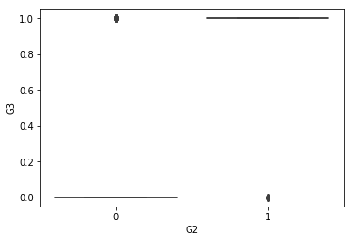

```python
sns.boxplot(x=data1['G2'],y=data1['G3'],data=data1)
```

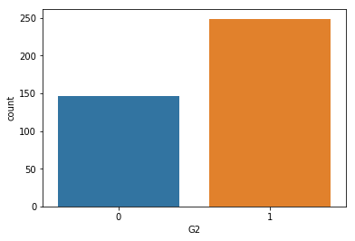

```python
sns.countplot(x='G2',data=X)
```

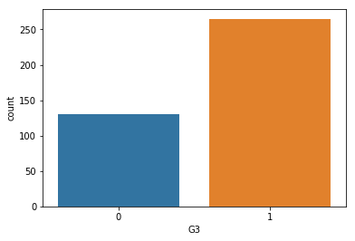

```python
sns.countplot(x='G3',data=data1)
```

```python
data1.corr()
```

|  | school | sex | age | address | famsize | Pstatus | Medu | Fedu | Mjob | Fjob | ... | higher | internet | romantic | goout | Walc | health | absences | G1 | G2 | G3 |
| --- | --- | --- | --- | --- | --- | --- | --- | --- | --- | --- | --- | --- | --- | --- | --- | --- | --- | --- | --- | --- | --- |
| school | 1.000000 | -0.012286 | 0.377610 | -0.279797 | 0.064866 | 0.045923 | -0.133333 | -0.079807 | -0.056670 | 0.018974 | ... | -0.024150 | -0.133578 | 0.060700 | -0.007152 | 0.065087 | -0.042651 | -0.088480 | -0.007620 | -0.049010 | -0.031254 |
| sex | -0.012286 | 1.000000 | -0.028606 | -0.028504 | 0.089862 | 0.023443 | 0.078228 | 0.034878 | 0.191421 | 0.084957 | ... | -0.151056 | 0.044113 | -0.102023 | 0.075897 | 0.274194 | 0.143588 | -0.066962 | 0.076348 | 0.064276 | 0.070618 |
| age | 0.377610 | -0.028606 | 1.000000 | -0.146722 | 0.037847 | 0.029598 | -0.163658 | -0.163438 | -0.069104 | -0.035191 | ... | -0.209081 | -0.112094 | 0.164669 | 0.126964 | 0.117276 | -0.062187 | 0.175230 | -0.062674 | -0.157843 | -0.179645 |
| address | -0.279797 | -0.028504 | -0.146722 | 1.000000 | 0.072472 | -0.042572 | 0.138804 | 0.072178 | 0.108818 | -0.001911 | ... | 0.042854 | 0.216842 | 0.005257 | 0.068835 | -0.101126 | -0.040355 | -0.027874 | 0.055338 | 0.094195 | 0.052282 |
| famsize | 0.064866 | 0.089862 | 0.037847 | 0.072472 | 1.000000 | -0.149612 | -0.043068 | -0.058879 | 0.071386 | -0.084448 | ... | -0.005806 | 0.000720 | 0.034395 | 0.023064 | 0.103425 | -0.028992 | 0.035783 | 0.034724 | 0.071031 | 0.041842 |
| Pstatus | 0.045923 | 0.023443 | 0.029598 | -0.042572 | -0.149612 | 1.000000 | -0.123565 | -0.088730 | -0.054476 | 0.033892 | ... | -0.040735 | 0.070074 | -0.040451 | 0.003459 | 0.006045 | 0.022307 | -0.134937 | -0.012787 | -0.019852 | -0.044050 |
| Medu | -0.133333 | 0.078228 | -0.163658 | 0.138804 | -0.043068 | -0.123565 | 1.000000 | 0.623455 | 0.454805 | 0.157920 | ... | 0.168845 | 0.201463 | 0.039681 | 0.064094 | -0.047123 | -0.046878 | 0.100285 | 0.204648 | 0.169848 | 0.115396 |
| Fedu | -0.079807 | 0.034878 | -0.163438 | 0.072178 | -0.058879 | -0.088730 | 0.623455 | 1.000000 | 0.243327 | 0.200169 | ... | 0.174566 | 0.127507 | 0.015602 | 0.043105 | -0.012631 | 0.014742 | 0.024473 | 0.209010 | 0.193714 | 0.108057 |
| Mjob | -0.056670 | 0.191421 | -0.069104 | 0.108818 | 0.071386 | -0.054476 | 0.454805 | 0.243327 | 1.000000 | 0.196758 | ... | 0.097887 | 0.216969 | -0.062999 | 0.003169 | -0.012051 | 0.065220 | 0.050254 | 0.073532 | 0.037497 | 0.026592 |
| Fjob | 0.018974 | 0.084957 | -0.035191 | -0.001911 | -0.084448 | 0.033892 | 0.157920 | 0.200169 | 0.196758 | 1.000000 | ... | -0.045250 | 0.035777 | -0.000583 | 0.010340 | 0.070024 | -0.018058 | 0.008196 | 0.036116 | 0.006251 | 0.028309 |
| reason | -0.090010 | -0.095867 | -0.015337 | -0.047891 | -0.019212 | -0.003553 | 0.117653 | 0.043099 | 0.022022 | -0.027688 | ... | 0.058504 | 0.049916 | 0.018894 | -0.050937 | -0.044699 | -0.157132 | 0.116909 | 0.071305 | 0.101407 | 0.099300 |
| guardian | 0.011109 | -0.071343 | 0.290485 | -0.044512 | -0.002718 | -0.108715 | -0.023918 | -0.133644 | 0.014787 | -0.080511 | ... | -0.020179 | -0.059394 | 0.093945 | 0.056557 | -0.040810 | -0.067497 | 0.163752 | -0.077274 | -0.121704 | -0.101407 |
| schoolsup | -0.139789 | -0.138271 | -0.251811 | 0.024712 | -0.028642 | -0.042238 | -0.036029 | 0.037530 | -0.040958 | -0.011657 | ... | 0.054486 | -0.009683 | -0.080716 | -0.037698 | -0.087152 | -0.034124 | 0.022526 | -0.152078 | -0.096181 | -0.099860 |
| famsup | -0.164967 | -0.151623 | -0.140609 | 0.023903 | -0.112893 | 0.019067 | 0.183727 | 0.185496 | 0.050667 | -0.030159 | ... | 0.100815 | 0.103581 | 0.012440 | -0.015631 | -0.086688 | 0.029297 | 0.024353 | -0.065009 | -0.027475 | -0.059219 |
| paid | -0.017083 | -0.129126 | -0.035933 | 0.052800 | -0.013882 | 0.046435 | 0.159700 | 0.086981 | 0.096566 | -0.040435 | ... | 0.189214 | 0.153132 | 0.005536 | 0.010493 | 0.060454 | -0.078132 | 0.007435 | 0.064257 | 0.083171 | 0.092665 |
| activities | -0.116946 | 0.099833 | -0.103063 | -0.051360 | -0.000113 | 0.097352 | 0.108277 | 0.112643 | 0.098754 | 0.032391 | ... | 0.096484 | 0.048663 | 0.019651 | 0.046088 | -0.037477 | 0.023923 | -0.013610 | 0.023832 | 0.045045 | 0.012414 |
| nursery | -0.089277 | -0.008203 | -0.086632 | 0.059589 | 0.102088 | -0.090615 | 0.193263 | 0.157177 | 0.095848 | -0.030812 | ... | 0.054303 | 0.007830 | 0.027495 | 0.004612 | -0.099534 | -0.018475 | 0.019155 | 0.024580 | 0.000789 | -0.008784 |
| higher | -0.024150 | -0.151056 | -0.209081 | 0.042854 | -0.005806 | -0.040735 | 0.168845 | 0.174566 | 0.097887 | -0.045250 | ... | 1.000000 | 0.020374 | -0.105664 | -0.039700 | -0.100340 | -0.015895 | -0.056085 | 0.139813 | 0.158064 | 0.157708 |
| internet | -0.133578 | 0.044113 | -0.112094 | 0.216842 | 0.000720 | 0.070074 | 0.201463 | 0.127507 | 0.216969 | 0.035777 | ... | 0.020374 | 1.000000 | 0.087122 | 0.074370 | 0.011687 | -0.080189 | 0.101701 | 0.060436 | 0.106919 | 0.061791 |
| romantic | 0.060700 | -0.102023 | 0.164669 | 0.005257 | 0.034395 | -0.040451 | 0.039681 | 0.015602 | -0.062999 | -0.000583 | ... | -0.105664 | 0.087122 | 1.000000 | 0.007870 | -0.010141 | 0.026342 | 0.153384 | 0.027438 | -0.069049 | -0.097737 |
| goout | -0.007152 | 0.075897 | 0.126964 | 0.068835 | 0.023064 | 0.003459 | 0.064094 | 0.043105 | 0.003169 | 0.010340 | ... | -0.039700 | 0.074370 | 0.007870 | 1.000000 | 0.420386 | -0.009577 | 0.044302 | -0.083237 | -0.193901 | -0.183399 |
| Walc | 0.065087 | 0.274194 | 0.117276 | -0.101126 | 0.103425 | 0.006045 | -0.047123 | -0.012631 | -0.012051 | 0.070024 | ... | -0.100340 | 0.011687 | -0.010141 | 0.420386 | 1.000000 | 0.092476 | 0.136291 | -0.068327 | -0.132493 | -0.029957 |
| health | -0.042651 | 0.143588 | -0.062187 | -0.040355 | -0.028992 | 0.022307 | -0.046878 | 0.014742 | 0.065220 | -0.018058 | ... | -0.015895 | -0.080189 | 0.026342 | -0.009577 | 0.092476 | 1.000000 | -0.029937 | -0.050424 | -0.064412 | -0.065668 |
| absences | -0.088480 | -0.066962 | 0.175230 | -0.027874 | 0.035783 | -0.134937 | 0.100285 | 0.024473 | 0.050254 | 0.008196 | ... | -0.056085 | 0.101701 | 0.153384 | 0.044302 | 0.136291 | -0.029937 | 1.000000 | -0.011447 | -0.091540 | -0.092244 |
| G1 | -0.007620 | 0.076348 | -0.062674 | 0.055338 | 0.034724 | -0.012787 | 0.204648 | 0.209010 | 0.073532 | 0.036116 | ... | 0.139813 | 0.060436 | 0.027438 | -0.083237 | -0.068327 | -0.050424 | -0.011447 | 1.000000 | 0.716061 | 0.642974 |
| G2 | -0.049010 | 0.064276 | -0.157843 | 0.094195 | 0.071031 | -0.019852 | 0.169848 | 0.193714 | 0.037497 | 0.006251 | ... | 0.158064 | 0.106919 | -0.069049 | -0.193901 | -0.132493 | -0.064412 | -0.091540 | 0.716061 | 1.000000 | 0.825393 |
| G3 | -0.031254 | 0.070618 | -0.179645 | 0.052282 | 0.041842 | -0.044050 | 0.115396 | 0.108057 | 0.026592 | 0.028309 | ... | 0.157708 | 0.061791 | -0.097737 | -0.183399 | -0.029957 | -0.065668 | -0.092244 | 0.642974 | 0.825393 | 1.000000 |

27 rows × 27 columns

The G3 depends a great deal on the G2. Thus, the G2 can be a good predictor of the outcome variable.

## Question 8

*Plot the number of students in each school and number of students with different ages in separate plots.*

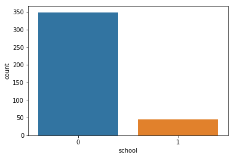

```python
sns.countplot(x='school',data=X)
```

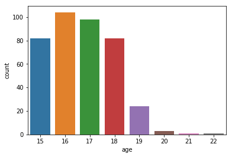

```python
sns.countplot(x='age',data=X)
```

## Question 9 - Training and testing data split

**Hint:** check **train_test_split()** from **sklearn**

#### Answer:

```python
X_train,X_test,y_train,y_test = train_test_split(X,y,test_size=0.3)
lg= LogisticRegression()
```

## Question 10 - Model Implementation and Testing the Accuracy

*Build a **LogisticRegression** classifier using **fit()** and **predict()** functions in sklearn. Print Accuracy and F1 score of Training and Test sets.*

#### Answer:

```python
lg.fit(X_train,y_train)
pred_train = lg.predict(X_train)
pred_test = lg.predict(X_test)
```

```python
# For obtaining the accuracy score

print("The accuracy obtained on train model is ",lg.score(X_train,y_train))
print("The accuracy obtained on train model is ",lg.score(X_test,y_test))
```

```
The accuracy obtained on train model is  0.9094202898550725
The accuracy obtained on train model is  0.9411764705882353
```

```python
# for obtaining the confusion matrix
print("The confusion matrix for train model is", metrics.confusion_matrix(y_train,pred_train))
print("The confusion matrix for test model is", metrics.confusion_matrix(y_test,pred_test))
```

```
The confusion matrix for train model is [[ 92   8]
 [ 17 159]]
The confusion matrix for test model is [[26  4]
 [ 3 86]]
```

```python
metrics.f1_score(y_train,pred_train,average = 'binary')
#metrics.f1_score(y_test,pred_test,,average = 'binary')
```

[output not shown]

# Naive bayes with Iris data

### Import Iris.csv

```python
data2 = pd.read_csv("Iris.csv")
data2
```

|  | Sepal Length (in cm) | Sepal Width in (cm) | Petal length (in cm) | Petal width (in cm) | Class |
| --- | --- | --- | --- | --- | --- |
| 0 | 5.1 | 3.5 | 1.4 | 0.2 | Iris-setosa |
| 1 | 4.9 | 3.0 | 1.4 | 0.2 | Iris-setosa |
| 2 | 4.7 | 3.2 | 1.3 | 0.2 | Iris-setosa |
| 3 | 4.6 | 3.1 | 1.5 | 0.2 | Iris-setosa |
| 4 | 5.0 | 3.6 | 1.4 | 0.2 | Iris-setosa |
| 5 | 5.4 | 3.9 | 1.7 | 0.4 | Iris-setosa |
| 6 | 4.6 | 3.4 | 1.4 | 0.3 | Iris-setosa |
| 7 | 5.0 | 3.4 | 1.5 | 0.2 | Iris-setosa |
| 8 | 4.4 | 2.9 | 1.4 | 0.2 | Iris-setosa |
| 9 | 4.9 | 3.1 | 1.5 | 0.1 | Iris-setosa |
| 10 | 5.4 | 3.7 | 1.5 | 0.2 | Iris-setosa |
| 11 | 4.8 | 3.4 | 1.6 | 0.2 | Iris-setosa |
| 12 | 4.8 | 3.0 | 1.4 | 0.1 | Iris-setosa |
| 13 | 4.3 | 3.0 | 1.1 | 0.1 | Iris-setosa |
| 14 | 5.8 | 4.0 | 1.2 | 0.2 | Iris-setosa |
| 15 | 5.7 | 4.4 | 1.5 | 0.4 | Iris-setosa |
| 16 | 5.4 | 3.9 | 1.3 | 0.4 | Iris-setosa |
| 17 | 5.1 | 3.5 | 1.4 | 0.3 | Iris-setosa |
| 18 | 5.7 | 3.8 | 1.7 | 0.3 | Iris-setosa |
| 19 | 5.1 | 3.8 | 1.5 | 0.3 | Iris-setosa |
| 20 | 5.4 | 3.4 | 1.7 | 0.2 | Iris-setosa |
| 21 | 5.1 | 3.7 | 1.5 | 0.4 | Iris-setosa |
| 22 | 4.6 | 3.6 | 1.0 | 0.2 | Iris-setosa |
| 23 | 5.1 | 3.3 | 1.7 | 0.5 | Iris-setosa |
| 24 | 4.8 | 3.4 | 1.9 | 0.2 | Iris-setosa |
| 25 | 5.0 | 3.0 | 1.6 | 0.2 | Iris-setosa |
| 26 | 5.0 | 3.4 | 1.6 | 0.4 | Iris-setosa |
| 27 | 5.2 | 3.5 | 1.5 | 0.2 | Iris-setosa |
| 28 | 5.2 | 3.4 | 1.4 | 0.2 | Iris-setosa |
| 29 | 4.7 | 3.2 | 1.6 | 0.2 | Iris-setosa |
| ... | ... | ... | ... | ... | ... |
| 120 | 6.9 | 3.2 | 5.7 | 2.3 | Iris-virginica |
| 121 | 5.6 | 2.8 | 4.9 | 2.0 | Iris-virginica |
| 122 | 7.7 | 2.8 | 6.7 | 2.0 | Iris-virginica |
| 123 | 6.3 | 2.7 | 4.9 | 1.8 | Iris-virginica |
| 124 | 6.7 | 3.3 | 5.7 | 2.1 | Iris-virginica |
| 125 | 7.2 | 3.2 | 6.0 | 1.8 | Iris-virginica |
| 126 | 6.2 | 2.8 | 4.8 | 1.8 | Iris-virginica |
| 127 | 6.1 | 3.0 | 4.9 | 1.8 | Iris-virginica |
| 128 | 6.4 | 2.8 | 5.6 | 2.1 | Iris-virginica |
| 129 | 7.2 | 3.0 | 5.8 | 1.6 | Iris-virginica |
| 130 | 7.4 | 2.8 | 6.1 | 1.9 | Iris-virginica |
| 131 | 7.9 | 3.8 | 6.4 | 2.0 | Iris-virginica |
| 132 | 6.4 | 2.8 | 5.6 | 2.2 | Iris-virginica |
| 133 | 6.3 | 2.8 | 5.1 | 1.5 | Iris-virginica |
| 134 | 6.1 | 2.6 | 5.6 | 1.4 | Iris-virginica |
| 135 | 7.7 | 3.0 | 6.1 | 2.3 | Iris-virginica |
| 136 | 6.3 | 3.4 | 5.6 | 2.4 | Iris-virginica |
| 137 | 6.4 | 3.1 | 5.5 | 1.8 | Iris-virginica |
| 138 | 6.0 | 3.0 | 4.8 | 1.8 | Iris-virginica |
| 139 | 6.9 | 3.1 | 5.4 | 2.1 | Iris-virginica |
| 140 | 6.7 | 3.1 | 5.6 | 2.4 | Iris-virginica |
| 141 | 6.9 | 3.1 | 5.1 | 2.3 | Iris-virginica |
| 142 | 5.8 | 2.7 | 5.1 | 1.9 | Iris-virginica |
| 143 | 6.8 | 3.2 | 5.9 | 2.3 | Iris-virginica |
| 144 | 6.7 | 3.3 | 5.7 | 2.5 | Iris-virginica |
| 145 | 6.7 | 3.0 | 5.2 | 2.3 | Iris-virginica |
| 146 | 6.3 | 2.5 | 5.0 | 1.9 | Iris-virginica |
| 147 | 6.5 | 3.0 | 5.2 | 2.0 | Iris-virginica |
| 148 | 6.2 | 3.4 | 5.4 | 2.3 | Iris-virginica |
| 149 | 5.9 | 3.0 | 5.1 | 1.8 | Iris-virginica |

150 rows × 5 columns

```python
data2.dtypes
```

```
Sepal Length (in cm)    float64
Sepal Width in (cm)     float64
Petal length (in cm)    float64
Petal width (in cm)     float64
Class                    object
dtype: object
```

```python
data2.info()
```

```
<class 'pandas.core.frame.DataFrame'>
RangeIndex: 150 entries, 0 to 149
Data columns (total 5 columns):
Sepal Length (in cm)    150 non-null float64
Sepal Width in (cm)     150 non-null float64
Petal length (in cm)    150 non-null float64
Petal width (in cm)     150 non-null float64
Class                   150 non-null object
dtypes: float64(4), object(1)
memory usage: 5.9+ KB
```

```python
data2.describe()
```

|  | Sepal Length (in cm) | Sepal Width in (cm) | Petal length (in cm) | Petal width (in cm) |
| --- | --- | --- | --- | --- |
| count | 150.000000 | 150.000000 | 150.000000 | 150.000000 |
| mean | 5.843333 | 3.054000 | 3.758667 | 1.198667 |
| std | 0.828066 | 0.433594 | 1.764420 | 0.763161 |
| min | 4.300000 | 2.000000 | 1.000000 | 0.100000 |
| 25% | 5.100000 | 2.800000 | 1.600000 | 0.300000 |
| 50% | 5.800000 | 3.000000 | 4.350000 | 1.300000 |
| 75% | 6.400000 | 3.300000 | 5.100000 | 1.800000 |
| max | 7.900000 | 4.400000 | 6.900000 | 2.500000 |

### Slice data set for Independent variables and dependent variables

```python
X= data2.drop('Class',axis=1)
X
```

|  | Sepal Length (in cm) | Sepal Width in (cm) | Petal length (in cm) | Petal width (in cm) |
| --- | --- | --- | --- | --- |
| 0 | 5.1 | 3.5 | 1.4 | 0.2 |
| 1 | 4.9 | 3.0 | 1.4 | 0.2 |
| 2 | 4.7 | 3.2 | 1.3 | 0.2 |
| 3 | 4.6 | 3.1 | 1.5 | 0.2 |
| 4 | 5.0 | 3.6 | 1.4 | 0.2 |
| 5 | 5.4 | 3.9 | 1.7 | 0.4 |
| 6 | 4.6 | 3.4 | 1.4 | 0.3 |
| 7 | 5.0 | 3.4 | 1.5 | 0.2 |
| 8 | 4.4 | 2.9 | 1.4 | 0.2 |
| 9 | 4.9 | 3.1 | 1.5 | 0.1 |
| 10 | 5.4 | 3.7 | 1.5 | 0.2 |
| 11 | 4.8 | 3.4 | 1.6 | 0.2 |
| 12 | 4.8 | 3.0 | 1.4 | 0.1 |
| 13 | 4.3 | 3.0 | 1.1 | 0.1 |
| 14 | 5.8 | 4.0 | 1.2 | 0.2 |
| 15 | 5.7 | 4.4 | 1.5 | 0.4 |
| 16 | 5.4 | 3.9 | 1.3 | 0.4 |
| 17 | 5.1 | 3.5 | 1.4 | 0.3 |
| 18 | 5.7 | 3.8 | 1.7 | 0.3 |
| 19 | 5.1 | 3.8 | 1.5 | 0.3 |
| 20 | 5.4 | 3.4 | 1.7 | 0.2 |
| 21 | 5.1 | 3.7 | 1.5 | 0.4 |
| 22 | 4.6 | 3.6 | 1.0 | 0.2 |
| 23 | 5.1 | 3.3 | 1.7 | 0.5 |
| 24 | 4.8 | 3.4 | 1.9 | 0.2 |
| 25 | 5.0 | 3.0 | 1.6 | 0.2 |
| 26 | 5.0 | 3.4 | 1.6 | 0.4 |
| 27 | 5.2 | 3.5 | 1.5 | 0.2 |
| 28 | 5.2 | 3.4 | 1.4 | 0.2 |
| 29 | 4.7 | 3.2 | 1.6 | 0.2 |
| ... | ... | ... | ... | ... |
| 120 | 6.9 | 3.2 | 5.7 | 2.3 |
| 121 | 5.6 | 2.8 | 4.9 | 2.0 |
| 122 | 7.7 | 2.8 | 6.7 | 2.0 |
| 123 | 6.3 | 2.7 | 4.9 | 1.8 |
| 124 | 6.7 | 3.3 | 5.7 | 2.1 |
| 125 | 7.2 | 3.2 | 6.0 | 1.8 |
| 126 | 6.2 | 2.8 | 4.8 | 1.8 |
| 127 | 6.1 | 3.0 | 4.9 | 1.8 |
| 128 | 6.4 | 2.8 | 5.6 | 2.1 |
| 129 | 7.2 | 3.0 | 5.8 | 1.6 |
| 130 | 7.4 | 2.8 | 6.1 | 1.9 |
| 131 | 7.9 | 3.8 | 6.4 | 2.0 |
| 132 | 6.4 | 2.8 | 5.6 | 2.2 |
| 133 | 6.3 | 2.8 | 5.1 | 1.5 |
| 134 | 6.1 | 2.6 | 5.6 | 1.4 |
| 135 | 7.7 | 3.0 | 6.1 | 2.3 |
| 136 | 6.3 | 3.4 | 5.6 | 2.4 |
| 137 | 6.4 | 3.1 | 5.5 | 1.8 |
| 138 | 6.0 | 3.0 | 4.8 | 1.8 |
| 139 | 6.9 | 3.1 | 5.4 | 2.1 |
| 140 | 6.7 | 3.1 | 5.6 | 2.4 |
| 141 | 6.9 | 3.1 | 5.1 | 2.3 |
| 142 | 5.8 | 2.7 | 5.1 | 1.9 |
| 143 | 6.8 | 3.2 | 5.9 | 2.3 |
| 144 | 6.7 | 3.3 | 5.7 | 2.5 |
| 145 | 6.7 | 3.0 | 5.2 | 2.3 |
| 146 | 6.3 | 2.5 | 5.0 | 1.9 |
| 147 | 6.5 | 3.0 | 5.2 | 2.0 |
| 148 | 6.2 | 3.4 | 5.4 | 2.3 |
| 149 | 5.9 | 3.0 | 5.1 | 1.8 |

150 rows × 4 columns

```python
y=data2['Class']
y
```

```
0         Iris-setosa
1         Iris-setosa
2         Iris-setosa
3         Iris-setosa
4         Iris-setosa
5         Iris-setosa
6         Iris-setosa
7         Iris-setosa
8         Iris-setosa
9         Iris-setosa
10        Iris-setosa
11        Iris-setosa
12        Iris-setosa
13        Iris-setosa
14        Iris-setosa
```

[output cut: 47 more lines]

### Find the distribution of target variable (Class)

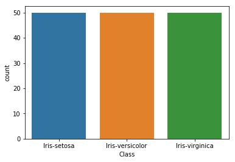

```python
sns.countplot(x='Class',data=data2)
```

### Plot the distribution of target variable using histogram

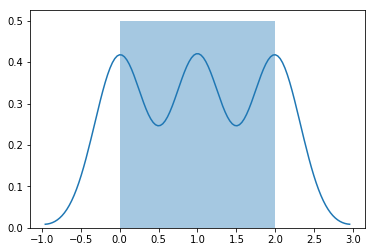

```python
#pd.value_counts(iris["Species"]).plot(kind="bar")
Y=encode_variable.fit_transform(y)
sns.distplot(Y)
```

### Plot Scatter Matrix to understand the distribution of variables and give insights from it( 1 Marks)

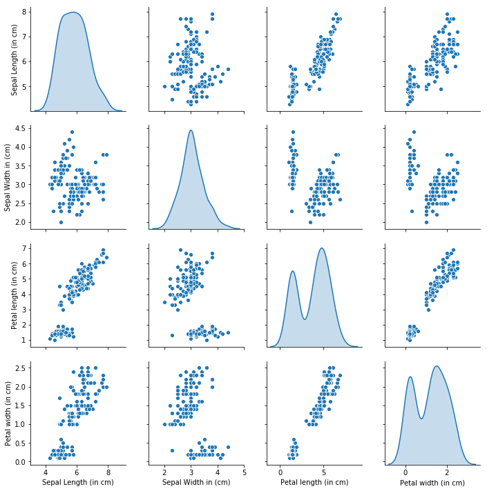

```python
sns.pairplot(data2,diag_kind='kde')
```

```python
data2.describe()
```

|  | Sepal Length (in cm) | Sepal Width in (cm) | Petal length (in cm) | Petal width (in cm) |
| --- | --- | --- | --- | --- |
| count | 150.000000 | 150.000000 | 150.000000 | 150.000000 |
| mean | 5.843333 | 3.054000 | 3.758667 | 1.198667 |
| std | 0.828066 | 0.433594 | 1.764420 | 0.763161 |
| min | 4.300000 | 2.000000 | 1.000000 | 0.100000 |
| 25% | 5.100000 | 2.800000 | 1.600000 | 0.300000 |
| 50% | 5.800000 | 3.000000 | 4.350000 | 1.300000 |
| 75% | 6.400000 | 3.300000 | 5.100000 | 1.800000 |
| max | 7.900000 | 4.400000 | 6.900000 | 2.500000 |

```python
data2.var()
```

```
Sepal Length (in cm)    0.685694
Sepal Width in (cm)     0.188004
Petal length (in cm)    3.113179
Petal width (in cm)     0.582414
dtype: float64
```

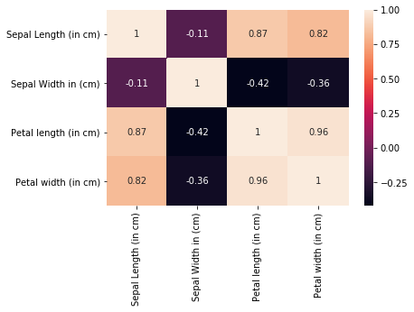

```python
sns.heatmap(data2.corr(),annot = True)
```

### Split data in Training and Validation in 80:20

```python
X_train,X_test,y_train,y_test=train_test_split(X,y,test_size=0.2)
```

### Do Feature Scaling

```python
X_train_fs=X_train.apply(zscore)
X_test_fs=X_test.apply(zscore)
```

### Train and Fit NaiveBayes Model

```python
naive_bayes_model = GaussianNB()
naive_bayes_model.fit(X_train_fs,y_train)
```

```
GaussianNB(priors=None, var_smoothing=1e-09)
```

```python
pred_train = naive_bayes_model.predict(X_train)
pred_test = naive_bayes_model.predict(X_test)
```

```python
metrics.f1_score(y_train,pred_train)
metrics.f1_score(y_test,pred_test)
```

[output not shown]

```python
# For obtaining the accuracy score

print("The accuracy obtained on train model is ",naive_bayes_model.score(X_train,y_train))
print("The accuracy obtained on train model is ",naive_bayes_model.score(X_test,y_test))
```

[output not shown]